# EBIII niveau 2 - Atelier RNA-Seq

Hugo Varet$^{1}$ - hugo.varet@pasteur.fr

Juin 2025

$^1$ Hub de Bioinformatique et Biostatistique, Centre de Ressources et Recherche en Informatique, Institut Pasteur

Ce fichier Rmarkdown contient tout le matériel de l’atelier RNA-Seq de l’école de Bioinformatique Aviesan/IFB/Inserm niveau 2. Diverses notions seront abordées à travers plusieurs types de designs expérimentaux :

- design simple avec 3 conditions,
- heatmaps,
- prise en compte d’un effet “batch”,
- conversion d’identifiants de gènes,
- analyse de *pathways*,
- design complexe avec 2 facteurs en interaction,

chacune d’entre-elles pouvant nécessiter plusieurs heures d’approfondissement d’un point de vue statistique/méthodologique. Nous les aborderons donc dans les grandes lignes tout en insistant sur certains concepts et détails clés.

Le code ci-dessous permet de charger les packages R dont nous allons avoir besoin :

```r
library(DESeq2)             # analyse differentielle
library(limma)              # removeBatchEffect et CAMERA
library(biomaRt)            # faire la correspondance ensembl id - gene name
library(gage)               # recuperer gene-sets KEGG
library(ggplot2)            # plots
library(plotly)             # plots interactifs
library(ggrepel)            # ajouter des labels sur les plots
library(ggbeeswarm)         # plots avancés
library(scales)             # transformation log2 dans ggplot
library(dplyr)              # manipulation de donnees
library(ggvenn)             # diagrammes de Venn
library(UpSetR)             # UpSet plot
library(FactoMineR)         # ACP
library(factoextra)         # plot de l'ACP
library(pheatmap)           # pretty heatmap
library(RColorBrewer)       # palette pour les heatmaps
library(ExploreModelMatrix) # application shiny interpretation design
library(devtools)           # session info
```

Les données utilisées proviennent de diverses expériences RNA-Seq et sont disponibles dans des fichiers au format `.RData` que nous chargerons avec la fonction `load()`. Chaque fichier `.RData` contient deux objets :

- `counts` : matrice de comptages avec les gènes en lignes et les échantillons en colonnes (après nettoyage, mapping et comptage des reads sur les gènes),
- `target` : `data.frame` décrivant le design expérimental.

On suppose que les données sont de bonne qualité et qu’il n’y a pas eu de problème durant l’extraction des ARN, la préparation des librairies et le séquençage. Aussi, il n’y a pas d’outlier ni d’inversion d’échantillon. En résumé, tous les contrôles ont été faits grâce à des statistiques/figures descriptives simples. Enfin, les échantillons sont nommés et ordonnés de la même manière dans le tableau de design et dans les comptages.

**Remarque** : certaines données ont été anonymisées en modifiant le contexte du design expérimental et en utilisant des identifiants de gènes du type `gene1`, `gene2`, …, `geneN`.

# 1 Analyse différentielle simple : étude d’un facteur à 3 niveaux

Le jeu de données utilisé ici provient d’une expérience sur un champignon dont l’objectif était de suivre l’évolution transcriptomique au cours du temps. Pour cela, nous avons séquencé l’ARN de 3 échantillons à T=0h, T=4h et à T=8h. On commence par afficher le design de l’expérience ainsi que la matrice de comptages obtenue :

```r
load("data_3_levels.RData")
ls()
```

```
## [1] "counts" "target"
```

```r
print(target)
```

```
##      label time replicate
## T0-1  T0-1   T0        r1
## T0-2  T0-2   T0        r2
## T0-3  T0-3   T0        r3
## T4-1  T4-1   T4        r1
## T4-2  T4-2   T4        r2
## T4-3  T4-3   T4        r3
## T8-1  T8-1   T8        r1
## T8-2  T8-2   T8        r2
## T8-3  T8-3   T8        r3
```

```r
print(head(counts))
```

```
##       T0-1 T0-2 T0-3 T4-1 T4-2 T4-3 T8-1 T8-2 T8-3
## gene1 2331 3079 3513 2250 3268 3141 1785 3488 2107
## gene2  772 1677  270 1023 1973  479 1165 1318  700
## gene3 2467 3655 3204 2442 3998 2595 1786 3032 1640
## gene4 4177 4632 5667 3798 5428 5543 3159 4880 3907
## gene5 4844 5501 6222 3731 4857 4522 3356 4906 2578
## gene6 3522 5206 3438 2643 5209 3239 1962 3163 1834
```

**Question** : que peut-on faire à partir de ces données et comment pouvons-nous les analyser ?

## 1.1 Utilisation de DESeq2

Les commandes suivantes permettent de créer un objet `dds` (qui est central et spécifique à l’analyse différentielle avec DESeq2) puis de réaliser les étapes suivantes :

1. la normalisation,
2. l’estimation de la dispersion,
3. l’ajustement du modèle linéaire généralisé.

```r
dds <- DESeqDataSetFromMatrix(countData=counts,
                              colData=target,
                              design=~time)
dds <- estimateSizeFactors(dds)
dds <- estimateDispersions(dds)
dds <- nbinomWaldTest(dds)
```

**Remarque** : nous utilisons ici DESeq2 avec le paramétrage par défaut, mais il existe de nombreuses subtilités mathématiques/statistiques. La [vignette](https://bioconductor.org/packages/release/bioc/vignettes/DESeq2/inst/doc/DESeq2.html) du package est extrêmement bien faite et explique les différentes options possibles.

Avant de passer à la recherche de gènes différentiellement exprimés, nous allons explorer la structure multidimensionnelle des données.

## 1.2 Hétéroscédasticité des données

L’analyse en composantes principales (ACP) est une méthode de réduction de la dimension qui permet d’explorer la structure du jeu de données et de le visualiser facilement sur un sous-espace bien choisi. Les figures générées permettent de détecter des échantillons outliers, des inversions, des effets “batch”, etc…

Les deux figures ci-dessous permettent de visualiser le caractère hétéroscédastique des données de comptages, et l’homoscédasticité après transformation `rlog`. Ce sont ces données transformées qui sont utilisées par les méthodes exploratoires telles que l’ACP car le calcul des distances entre les échantillons ne doit pas être *drivé* par seulement quelques gènes fortement exprimés.

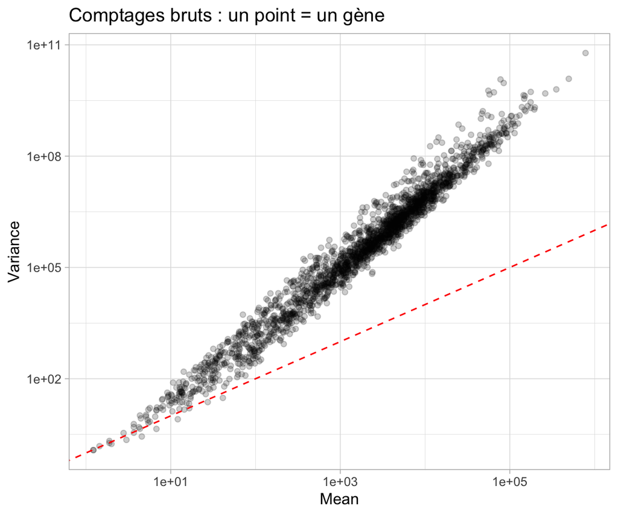

```r
data.frame(m=apply(counts, 1, mean) + 1, v=apply(counts, 1, var) + 1) %>%
  ggplot(aes(m, v)) +
  scale_x_log10() +
  scale_y_log10() +
  geom_point(alpha=0.2) +
  geom_abline(slope=1, intercept=0, linetype="dashed", col="red") +
  xlab("Mean") +
  ylab("Variance") +
  ggtitle("Comptages bruts : un point = un gène") +
  theme_light()
```

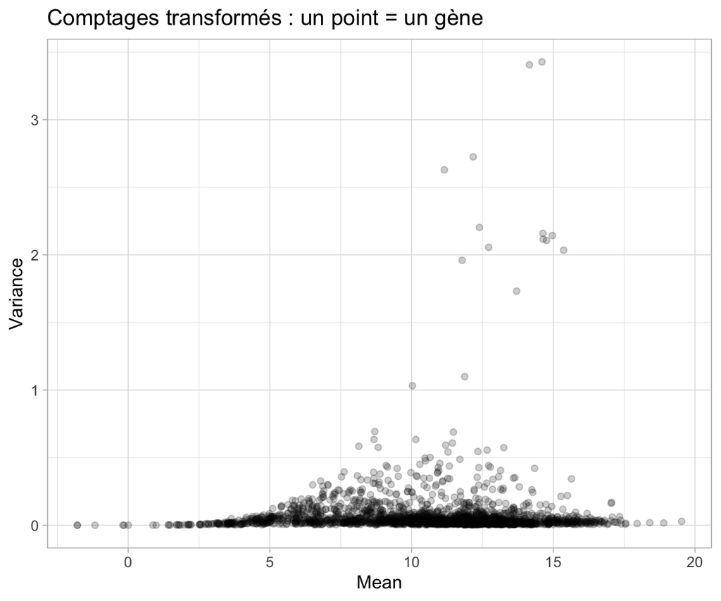

```r
rld <- rlog(dds)
data.frame(m=apply(assay(rld), 1, mean), v=apply(assay(rld), 1, var)) %>%
  ggplot(aes(m, v)) +
  geom_point(alpha=0.2) +
  xlab("Mean") +
  ylab("Variance") +
  ggtitle("Comptages transformés : un point = un gène") +
  theme_light()
```

## 1.3 Analyse en composantes principales

On utilise les données rendues homoscédastiques grâce à la méthode `rlog()` puis la fonction `plotPCA()` disponible dans DESeq2 :

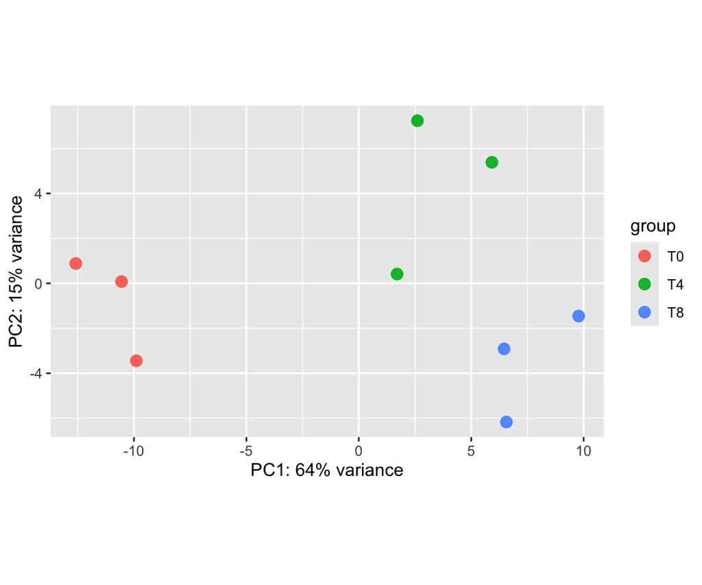

```r
plotPCA(rld, intgroup="time")
```

Une alternative est d’utiliser les packages R FactoMineR et factoextra afin d’avoir plus de flexibilité :

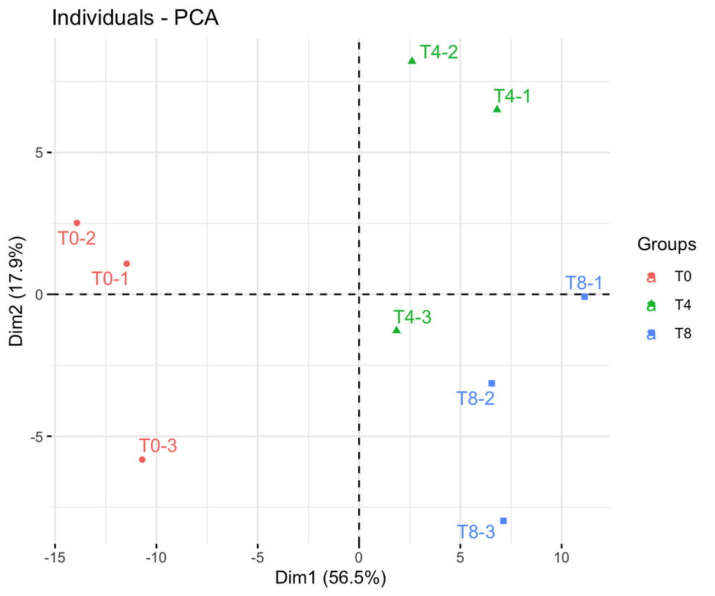

```r
pca <- PCA(t(assay(rld)), scale.unit=FALSE, ncp=3, graph=FALSE)
fviz_pca_ind(pca, axes=c(1, 2), repel=TRUE, habillage=factor(target$time), mean.point=FALSE)
```

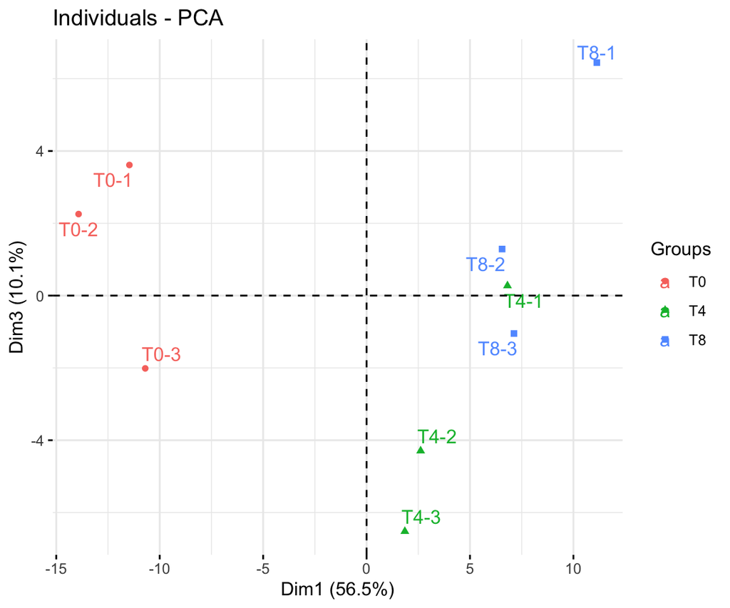

```r
fviz_pca_ind(pca, axes=c(1, 3), repel=TRUE, habillage=factor(target$time), mean.point=FALSE)
```

**Question** : pourquoi y a-t-il une différence entre les deux approches (`plotPCA()` de DESeq2 et `PCA()` de FactoMineR) ?

## 1.4 Tests des 3 comparaisons

Le code ci-dessous permet d’extraire toutes les comparaisons 2 à 2 :

- 4h vs 0h,
- 8h vs 0h,
- 8h vs 4h,

et d’afficher un MA-plot :

```r
resultsNames(dds)
```

```
## [1] "Intercept"     "time_T4_vs_T0" "time_T8_vs_T0"
```

```r
# interpretation des coefficients
# ExploreModelMatrix() pour lancer l'application Shiny
res_4vs0 <- lfcShrink(dds, contrast=c("time", "T4", "T0"), type="ashr", quiet=TRUE)
res_8vs0 <- lfcShrink(dds, contrast=c("time", "T8", "T0"), type="ashr", quiet=TRUE)
res_8vs4 <- lfcShrink(dds, contrast=c("time", "T8", "T4"), type="ashr", quiet=TRUE)
summary(res_4vs0, alpha=0.05)
```

```
##
## out of 2169 with nonzero total read count
## adjusted p-value < 0.05
## LFC > 0 (up)       : 348, 16%
## LFC < 0 (down)     : 186, 8.6%
## outliers [1]       : 0, 0%
## low counts [2]     : 0, 0%
## (mean count < 0)
## [1] see 'cooksCutoff' argument of ?results
## [2] see 'independentFiltering' argument of ?results
```

```r
summary(res_8vs0, alpha=0.05)
```

```
##
## out of 2169 with nonzero total read count
## adjusted p-value < 0.05
## LFC > 0 (up)       : 378, 17%
## LFC < 0 (down)     : 319, 15%
## outliers [1]       : 0, 0%
## low counts [2]     : 0, 0%
## (mean count < 0)
## [1] see 'cooksCutoff' argument of ?results
## [2] see 'independentFiltering' argument of ?results
```

```r
summary(res_8vs4, alpha=0.05)
```

```
##
## out of 2169 with nonzero total read count
## adjusted p-value < 0.05
## LFC > 0 (up)       : 36, 1.7%
## LFC < 0 (down)     : 57, 2.6%
## outliers [1]       : 0, 0%
## low counts [2]     : 0, 0%
## (mean count < 0)
## [1] see 'cooksCutoff' argument of ?results
## [2] see 'independentFiltering' argument of ?results
```

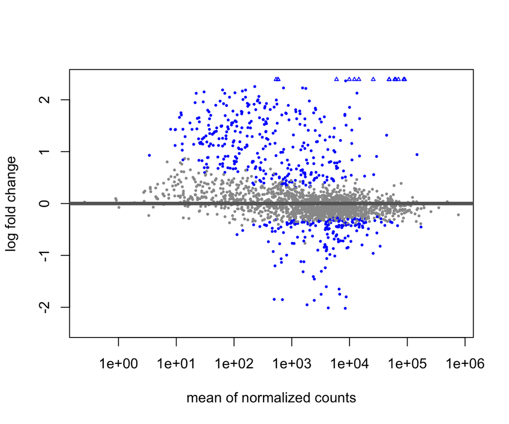

```r
# MA-plot de la comparaison 4h vs 0h
DESeq2::plotMA(res_4vs0, alpha=0.05)
```

Ce MA-plot est produit grâce à une fonction du package DESeq2. Il est possible de le reproduire manuellement et en ajoutant une couche d’interactivité :

```r
p <- res_4vs0 %>%
  as.data.frame() %>%
  mutate(DE=ifelse(!is.na(padj) & padj <= 0.05, "DE", "Not DE")) %>%
  mutate(id=rownames(res_4vs0)) %>%
  ggplot(aes(x=baseMean, y=log2FoldChange, color=DE, label=id)) +
  geom_point(alpha=0.4) +
  labs(color="4h vs 0h") +
  geom_hline(yintercept=0, linetype="dashed", color="grey") +
  scale_color_manual(values=c("DE"="red", "Not DE"="black")) +
  scale_x_log10() +
  theme_light()
toWebGL(ggplotly(p, tooltip="label"))
```

[interactive chart not shown]

On peut aussi ajouter les noms de certains gènes bien choisis :

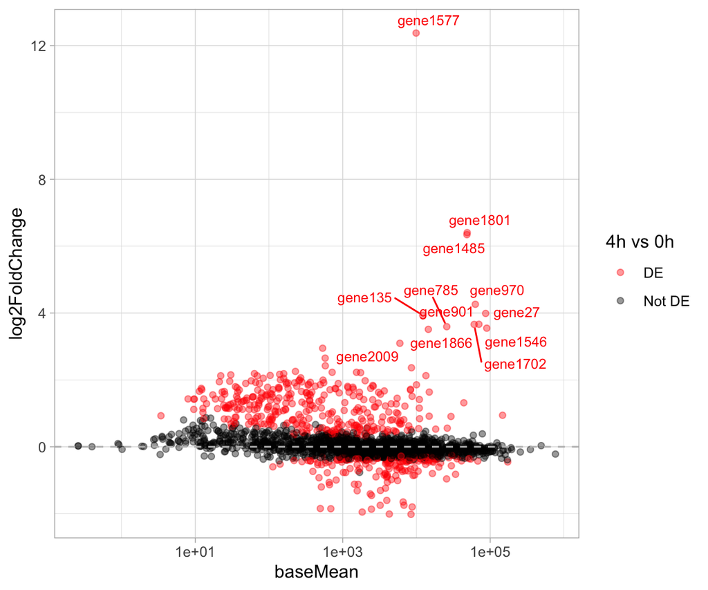

```r
res_4vs0 %>%
  as.data.frame() %>%
  mutate(DE=ifelse(!is.na(padj) & padj <= 0.05, "DE", "Not DE")) %>%
  mutate(id=ifelse(log2FoldChange > 3, rownames(res_4vs0), "")) %>%
  ggplot(aes(x=baseMean, y=log2FoldChange, color=DE, label=id)) +
  geom_point(alpha=0.4) +
  labs(color="4h vs 0h") +
  geom_text_repel(show.legend=FALSE, size=3, point.padding=0.2, max.overlaps=20) +
  geom_hline(yintercept=0, linetype="dashed", color="grey") +
  scale_color_manual(values=c("DE"="red", "Not DE"="black")) +
  scale_x_log10() +
  theme_light()
```

## 1.5 Croisement des résultats

Etant donné le design expérimental, nous avons obtenus les résultats d’une analyse différentielle pour 3 comparaisons. L’objectif est ici de croiser ces résultats sous la meilleure forme possible, mais nous devons pour cela nous assurer que les gènes sont ordonnés de la même manière dans les 3 objets `res_4vs0`, `res_8vs0` et `res_8vs4` :

```r
all(rownames(res_4vs0) == rownames(res_8vs0)) & all(rownames(res_4vs0) == rownames(res_8vs4))
```

```
## [1] TRUE
```

Une manière assez naturelle est de croiser les listes de gènes différentiellement exprimés, en fixant par exemple un seuil de 5% sur la p-valeur ajustée. Ainsi, nous pouvons détecter des gènes dérégulés spécifiquement à 8h mais qui ne l’étaient pas à 4h. Les diagrammes de Venn sont souvent utilisés pour faire cela :

```r
d <- data.frame(gene=rownames(res_4vs0),
                log2FC_4vs0=res_4vs0$log2FoldChange, padj_4vs0=res_4vs0$padj,
                log2FC_8vs0=res_8vs0$log2FoldChange, padj_8vs0=res_8vs0$padj,
                log2FC_8vs4=res_8vs4$log2FoldChange, padj_8vs4=res_8vs4$padj)
print(head(d), digits=3)
```

```
##    gene log2FC_4vs0 padj_4vs0 log2FC_8vs0 padj_8vs0 log2FC_8vs4 padj_8vs4
## 1 gene1     0.01005    0.9649      0.0438    0.8398     0.01630     0.952
## 2 gene2     0.07783    0.7625      0.1605    0.5879     0.01461     0.951
## 3 gene3    -0.00112    0.9950     -0.1656    0.3724    -0.09092     0.621
## 4 gene4     0.05119    0.8084      0.0681    0.7501     0.00289     0.998
## 5 gene5    -0.22933    0.0608     -0.2644    0.0366    -0.01051     0.972
## 6 gene6    -0.06300    0.7622     -0.3609    0.0805    -0.14105     0.411
```

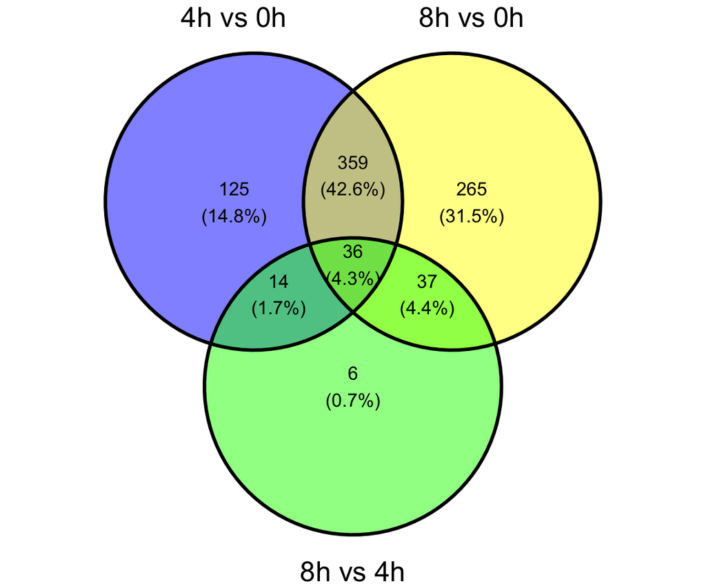

```r
x <- list("4h vs 0h"=d %>% filter(padj_4vs0 <= 0.05) %>% pull(gene),
          "8h vs 0h"=d %>% filter(padj_8vs0 <= 0.05) %>% pull(gene),
          "8h vs 4h"=d %>% filter(padj_8vs4 <= 0.05) %>% pull(gene))
ggvenn(x)
```

Le diagramme généré est plutôt lisible car nous avons croisé seulement 3 listes. Pour croiser davantage de données, les UpSet plots ont récemment vu le jour et sont souvent plus adaptés :

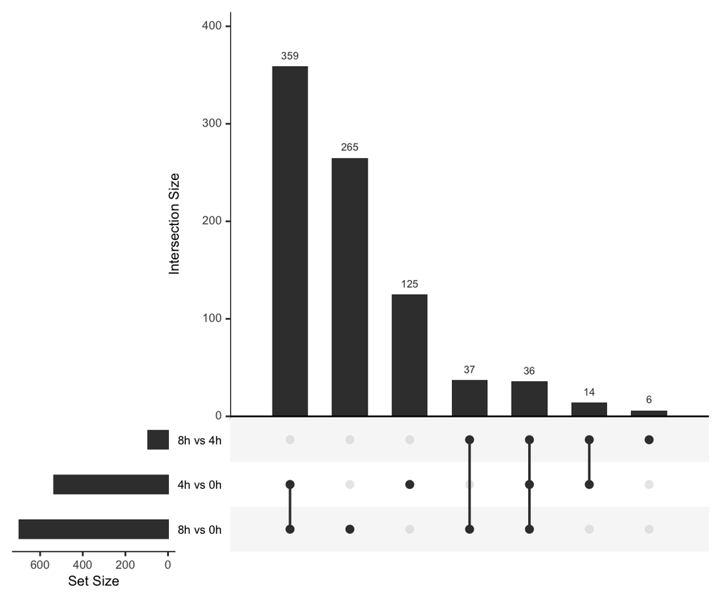

```r
upset(fromList(x), order.by="freq")
```

**Question** : comment interpréter les chiffres issus du diagramme de Venn et de l’UpSet plot ?

Les UpSet plots sont souvent plus lisibles que les diagrammes de Venn mais ont toujours l’inconvénient d’avoir des “effets de seuil”. L’exemple ci-dessous permet de comprendre ce qu’il peut se passer :

```r
d %>%
  filter(abs(log2FC_8vs0 - log2FC_4vs0) < 0.1) %>%
  filter(padj_4vs0 > 0.05 & padj_8vs0 < 0.05) %>%
  dplyr::select(contains(c("gene", "log2FC", "padj"))) %>%
  head()
```

```
##      gene log2FC_4vs0 log2FC_8vs0 log2FC_8vs4  padj_4vs0  padj_8vs0 padj_8vs4
## 1   gene5  -0.2293309  -0.2644350 -0.01050506 0.06083904 0.03657322 0.9722079
## 2 gene374  -0.2786602  -0.3524606 -0.01992609 0.06849556 0.03167935 0.9484213
## 3 gene467  -0.2538975  -0.3431442 -0.03324774 0.07968930 0.02544719 0.8991029
## 4 gene473  -0.2855411  -0.3302746 -0.00588014 0.05550870 0.03794243 0.9912358
## 5 gene523  -0.2069653  -0.3004383 -0.04890325 0.10319406 0.02013790 0.8363462
## 6 gene716  -0.2702907  -0.3253369 -0.01213579 0.06908139 0.04138005 0.9705380
```

Par exemple, au seuil de 5%, le gène 5 est différentiellement exprimé à 8h mais pas à 4h. Pourtant, les log2(Fold-Change) à 4h et à 8h sont très proches ($-0,23$ et $-0,26$), tout comme les P-valeurs ajustées ($0,06$ et $0,04$). On constate d’ailleurs que la différence entre 4h et 8h n’est pas significative (P-valeur ajustée = $0,97$). Nous allons donc construire une figure qui permet de visualiser au mieux tous les résultats simultanément :

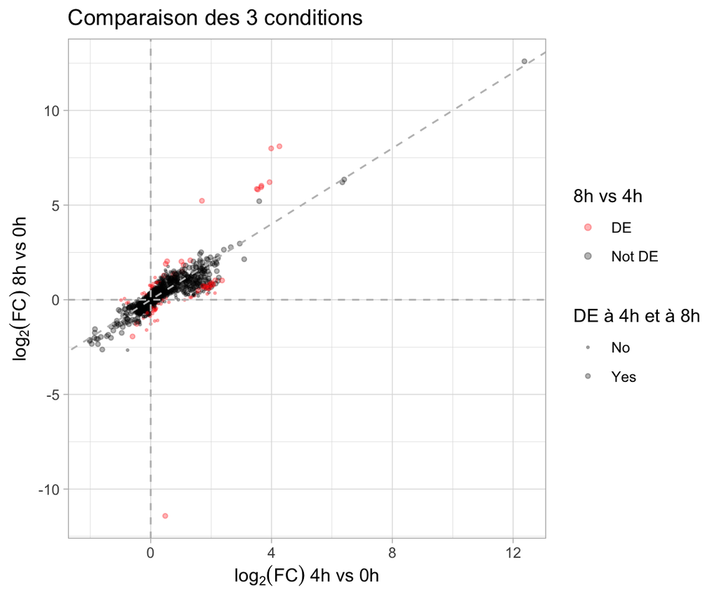

```r
d <- d %>%
  mutate(DE_8vs4=ifelse(!is.na(padj_8vs4) & padj_8vs4 <= 0.05, "DE", "Not DE"),
         DE_both_times=ifelse(!is.na(padj_4vs0) & padj_4vs0 <= 0.05 & !is.na(padj_8vs0) & padj_8vs0 <= 0.05, "Yes", "No"))
ggplot(d, aes(x=log2FC_4vs0, y=log2FC_8vs0, color=DE_8vs4, size=DE_both_times)) +
  geom_point(alpha=0.3) +
  scale_color_manual(values=c("DE"="red", "Not DE"="black")) +
  scale_size_manual(values=c("Yes"=1, "No"=0.4)) +
  geom_hline(yintercept=0, lty=2, color="grey") +
  geom_vline(xintercept=0, lty=2, color="grey") +
  geom_abline(slope=1, intercept=0, lty=2, color="grey") +
  labs(color="8h vs 4h", size="DE à 4h et à 8h") +
  xlab(bquote(log[2](FC)~"4h vs 0h")) +
  ylab(bquote(log[2](FC)~"8h vs 0h")) +
  ggtitle("Comparaison des 3 conditions") +
  theme_light()
```

Cette figure permet de repérer certains gènes pour lesquels l’effet à 4h est différent de l’effet à 8h, chacun de ces deux effets pouvant être significatifs ou non. On peut alors construire des filtres en fonction de la question biologique, par exemple :

```r
d %>%
  filter(padj_8vs4 <= 0.05 & abs(log2FC_8vs4) > 2) %>%
  dplyr::select(contains(c("gene", "log2FC", "padj")))
```

```
##      gene log2FC_4vs0 log2FC_8vs0 log2FC_8vs4    padj_4vs0    padj_8vs0    padj_8vs4
## 1  gene27   3.9889546    7.994236    3.674804 9.962520e-21 3.678433e-76 3.074497e-16
## 2 gene322   0.4810958  -11.417758  -12.140662 1.529902e-02 1.448189e-61 5.244541e-68
## 3 gene898   1.6960953    5.228053    3.407727 1.314652e-09 2.950421e-83 1.085497e-35
## 4 gene970   4.2622347    8.106160    3.574516 2.723993e-25 6.628782e-86 9.362211e-17
```

## 1.6 Heatmaps

Les heatmaps sont également souvent utilisées pour visualiser les résultats. Pour autant, celles-ci sont plus complexes qu’il n’y parait et il existe de nombreux paramètres à définir :

- quels gènes inclure ?
- afficher leurs identifiants ou noms ?
- clusteriser les lignes ? colonnes ? selon quelle méthode ?
- centrer/réduire les lignes ? colonnes ?
- quelle échelle de couleur choisir ?
- prendre en compte un éventuel effet réplicat/batch ?

Le code R ci-dessous permet de sélectionner les gènes différentiellement exprimés dans les 3 comparaisons (avec un seuil de 0.001 sur la P-valeur ajustée) et d’afficher une heatmap (i) sans paramétrage spécifique et (ii) en spécifiant certains paramètres.

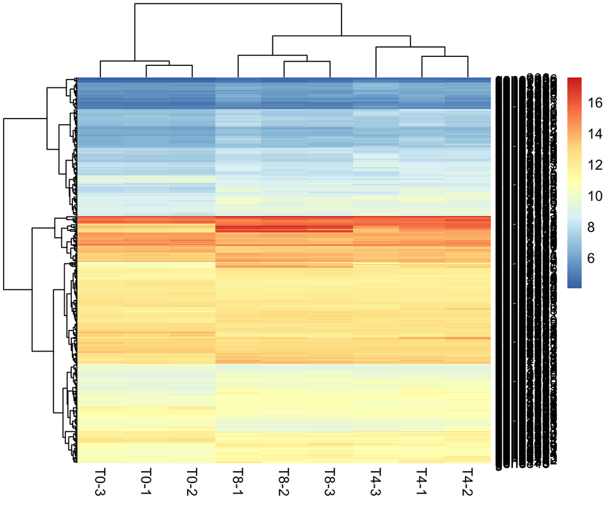

```r
DE_genes <- d %>%
  filter(padj_4vs0 <= 0.001 | padj_8vs0 <= 0.001 | padj_8vs4 <= 0.001) %>%
  pull(gene)
mat_hm <- assay(rlog(dds))
pheatmap(mat_hm[DE_genes, ])
```

**Question** : quel message renvoie cette heatmap ? Pourquoi ?

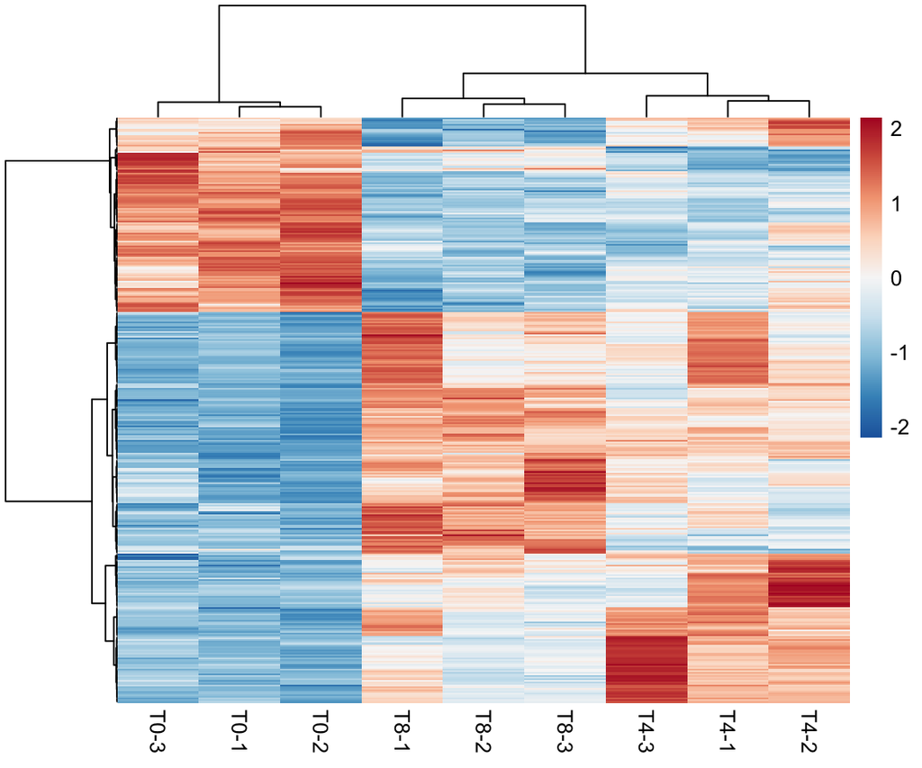

```r
pheatmap(mat_hm[DE_genes, ],
         scale="row",
         show_rownames=FALSE,
         clustering_distance_rows="euclidean",
         clustering_distance_cols="euclidean",
         clustering_method="ward.D",
         color=colorRampPalette(rev(brewer.pal(9, "RdBu")))(200))
```

**Questions** :

- pourquoi cette nouvelle heatmap est-elle si différente de la première ? En quoi est-elle plus adaptée ?
- le clustering est-il réalisé à partir des données brutes ou centrées-réduites ?

On peut également visualiser les log2(Fold-Change) plutôt que les données d’expression. Le code R ci-dessous permet de faire cela pour un certain nombre de gènes pré-sélectionnés :

```r
rownames(d) <- d$gene
d <- d %>%
  filter(padj_8vs4 <= 0.05 & (padj_4vs0 <= 0.05 | padj_8vs0 <= 0.05)) %>%
  filter(abs(log2FC_8vs0 - log2FC_4vs0) > 1) %>%
  dplyr::select(log2FC_4vs0, log2FC_8vs0) %>%
  as.matrix()
print(head(d))
```

```
##         log2FC_4vs0  log2FC_8vs0
## gene27    3.9889546  7.994236337
## gene135   3.9349746  6.211718231
## gene213   1.4518787  0.215970665
## gene220   1.1212949 -0.009835288
## gene237   1.7449549  0.733371069
## gene287   0.1331511 -1.122335229
```

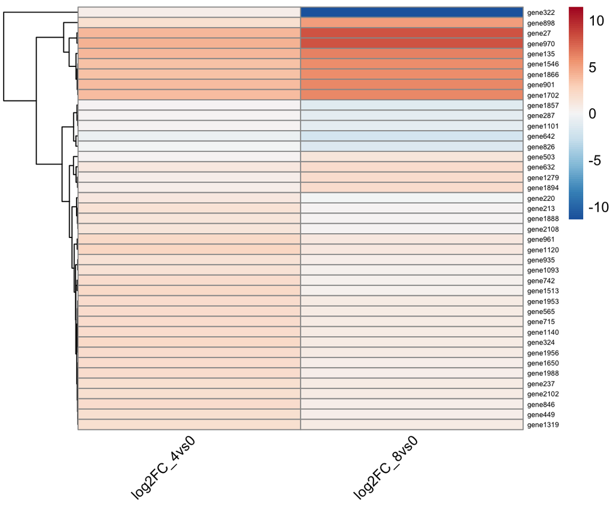

```r
pheatmap(d,
         scale="none",
         cluster_cols=FALSE,
         clustering_distance_rows="euclidean",
         angle_col=45,
         fontsize_row=5,
         color=colorRampPalette(rev(brewer.pal(9, "RdBu")))(100),
         breaks=seq(-max(abs(d)), max(abs(d)), length=101))
```

La heatmap produite est influencée par quelques gènes ayant des log2(Fold-Change) très élevés ou très faibles. Dans ce cas, on peut borner l’échelle de couleur de manière à faire ressortir les autres gènes plus facilement. Toutefois, il faut faire attention à ne pas déformer la figure :

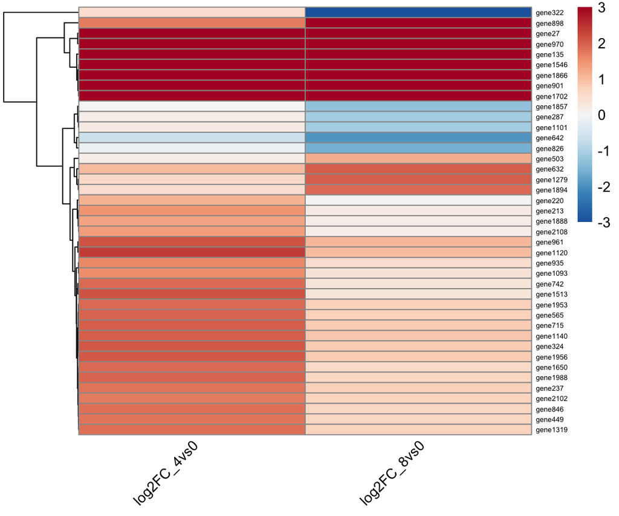

```r
pheatmap(d,
         scale="none",
         cluster_cols=FALSE,
         clustering_distance_rows="euclidean",
         angle_col=45,
         fontsize_row=5,
         color=colorRampPalette(rev(brewer.pal(9, "RdBu")))(100),
         breaks=seq(-3, 3, length=101))
```

# 2 Prise en compte d’un effet batch

Nous utilisons ici un jeu de données RNA-Seq humain : un traitement expérimental T et un traitement contrôle C ont été appliqués sur des cultures cellulaires provenant de 3 donneurs indépendants, l’objectif étant de détecter les gènes dérégulés par l’effet du traitement.

```r
rm(list=ls())
load("data_batch_effect.RData")
ls()
```

```
## [1] "counts" "target"
```

```r
print(target)
```

```
##       label condition donor
## C-d03 C-d03         C   d03
## C-d08 C-d08         C   d08
## C-d12 C-d12         C   d12
## T-d03 T-d03         T   d03
## T-d08 T-d08         T   d08
## T-d12 T-d12         T   d12
```

```r
print(head(counts))
```

```
##                 C-d03 C-d08 C-d12 T-d03 T-d08 T-d12
## ENSG00000000003    64    55    37    62    45    50
## ENSG00000000005     0     0     0     0     0     0
## ENSG00000000419  8370  5420  6154  7823  5283  5849
## ENSG00000000457   970   811   567   950   669   545
## ENSG00000000460  1689  1113   981  2065  1082  1264
## ENSG00000000938    44    25    10    24     5     1
```

## 2.1 Analyse en composantes principales

Commençons par créer l’objet `dds` à partir des comptages et du tableau de design :

```r
dds <- DESeqDataSetFromMatrix(countData=counts,
                              colData=target,
                              design=~condition)
```

**Question** : que révèle l’analyse en composante principale ?

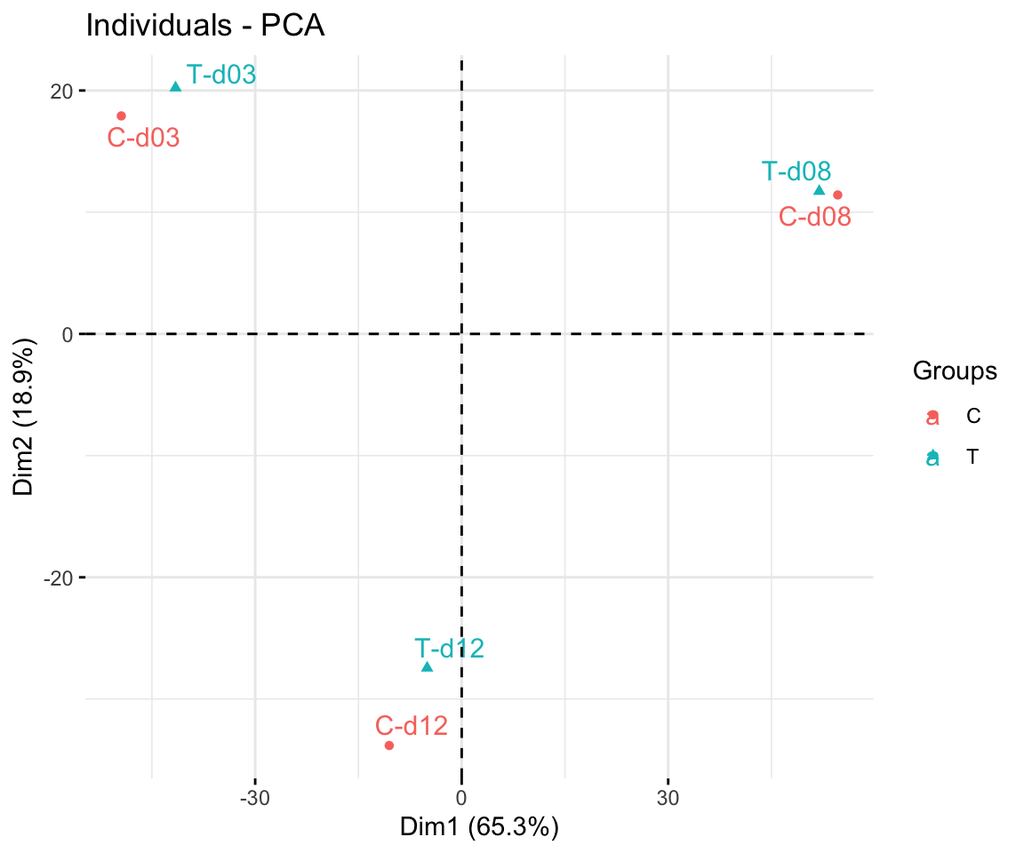

```r
rld <- rlog(dds)
pca <- PCA(t(assay(rld)), scale.unit=FALSE, ncp=3, graph=FALSE)
fviz_pca_ind(pca, axes=c(1, 2), repel=TRUE, habillage=factor(target$condition), mean.point=FALSE)
```

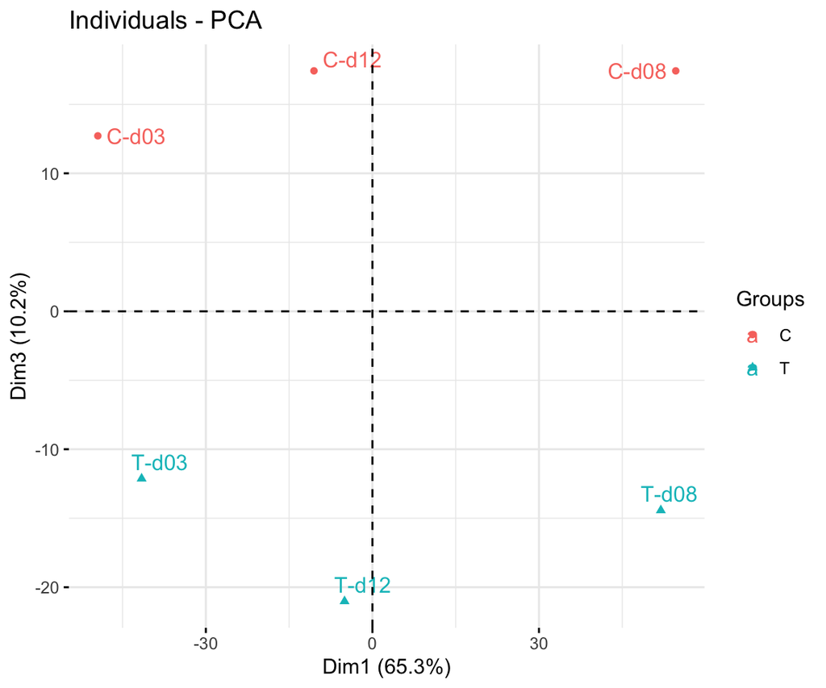

```r
fviz_pca_ind(pca, axes=c(1, 3), repel=TRUE, habillage=factor(target$condition), mean.point=FALSE)
```

## 2.2 Importance du design dans DESeq2

Le code ci-dessous permet de réaliser l’analyse différentielle et visualiser la distribution des p-valeurs brutes :

```r
dds <- estimateSizeFactors(dds)
dds <- estimateDispersions(dds)
dds <- nbinomWaldTest(dds)
resultsNames(dds)
```

```
## [1] "Intercept"        "condition_T_vs_C"
```

```r
res <- lfcShrink(dds, coef="condition_T_vs_C", type="ashr", quiet=TRUE)
summary(res, alpha=0.05)
```

```
##
## out of 32453 with nonzero total read count
## adjusted p-value < 0.05
## LFC > 0 (up)       : 17, 0.052%
## LFC < 0 (down)     : 69, 0.21%
## outliers [1]       : 106, 0.33%
## low counts [2]     : 10723, 33%
## (mean count < 3)
## [1] see 'cooksCutoff' argument of ?results
## [2] see 'independentFiltering' argument of ?results
```

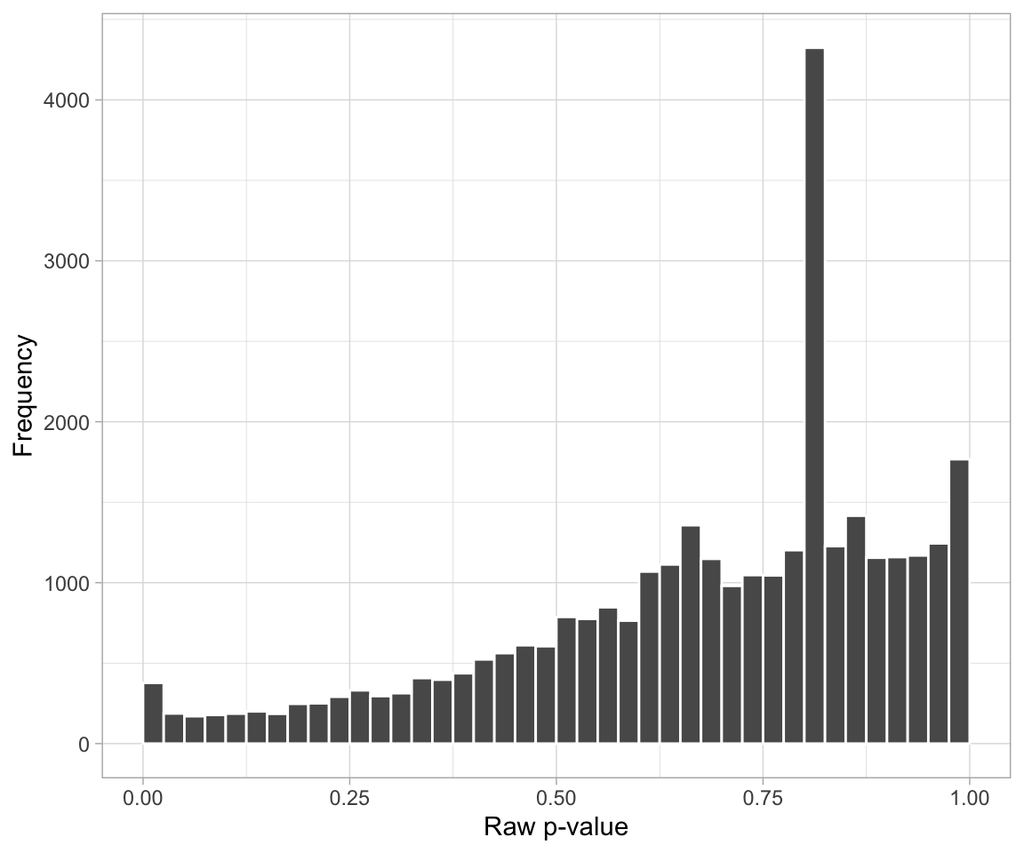

```r
ggplot(as.data.frame(res), aes(x=pvalue)) +
  geom_histogram(color="white", breaks=seq(0, 1, by=0.025)) +
  xlab("Raw p-value") +
  ylab("Frequency") +
  theme_light()
```

La distribution n’est pas celle attendue car la variabilité (information) générée par l’effet “donneur” n’est pas prise en compte dans le modèle. Nous pouvons visualiser ci-dessous cette variabilité pour un seul gène (bien choisi) :

```r
ncounts <- counts(dds, norm=TRUE)
d <- data.frame(target, counts=ncounts["ENSG00000066279",])
print(d)
```

```
##       label condition donor    counts
## C-d03 C-d03         C   d03  575.2294
## C-d08 C-d08         C   d08 3654.0259
## C-d12 C-d12         C   d12  378.6506
## T-d03 T-d03         T   d03 1095.8348
## T-d08 T-d08         T   d08 4831.8431
## T-d12 T-d12         T   d12  598.5342
```

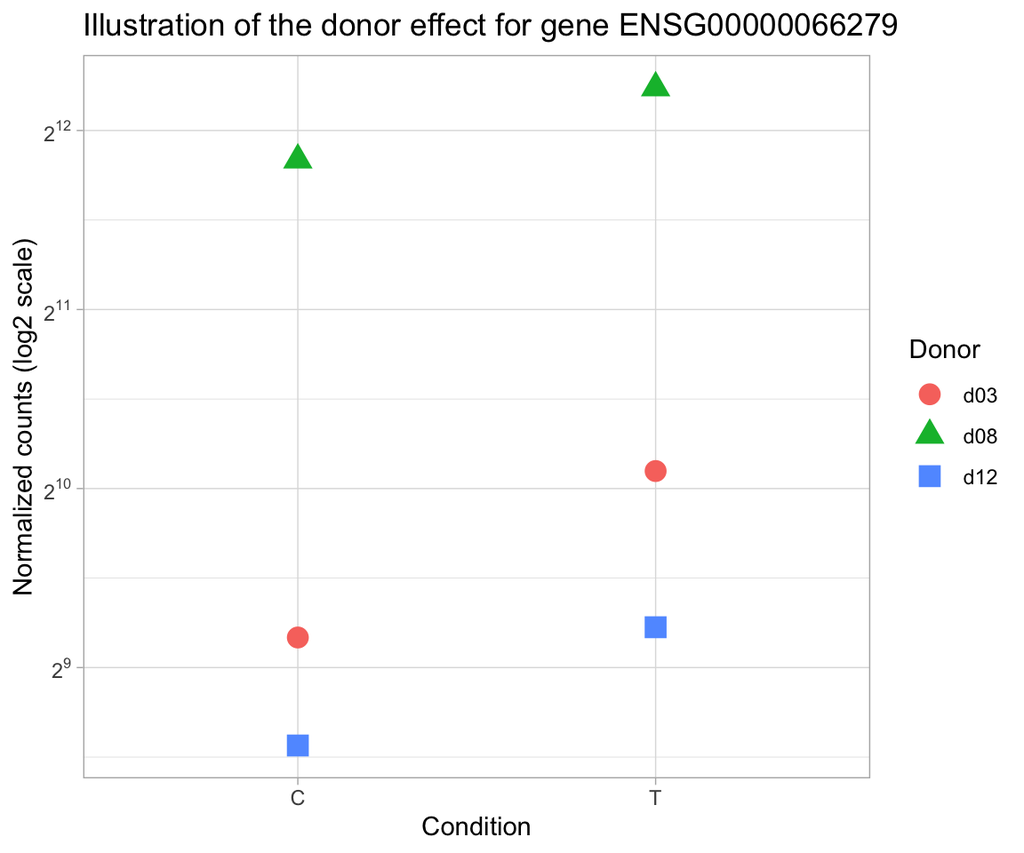

```r
ggplot(d, aes(x=condition, y=counts, color=donor, shape=donor)) +
  geom_point(size=4) +
  scale_y_continuous(trans=log2_trans(),
    breaks=trans_breaks("log2", function(x) 2^x),
    labels=trans_format("log2", math_format(2^.x))) +
  xlab("Condition") +
  ylab("Normalized counts (log2 scale)") +
  labs(shape="Donor", color="Donor") +
  ggtitle("Illustration of the donor effect for gene ENSG00000066279") +
  theme_light()
```

Il est nécessaire de spécifier dans le design du modèle cet effet “donneur” :

```r
dds <- DESeqDataSetFromMatrix(countData=counts,
                              colData=target,
                              design=~donor+condition)
dds <- estimateSizeFactors(dds)
dds <- estimateDispersions(dds)
dds <- nbinomWaldTest(dds)
resultsNames(dds)
```

```
## [1] "Intercept"        "donor_d08_vs_d03" "donor_d12_vs_d03" "condition_T_vs_C"
```

```r
res <- lfcShrink(dds, coef="condition_T_vs_C", type="ashr", quiet=TRUE)
summary(res, alpha=0.05)
```

```
##
## out of 32453 with nonzero total read count
## adjusted p-value < 0.05
## LFC > 0 (up)       : 577, 1.8%
## LFC < 0 (down)     : 729, 2.2%
## outliers [1]       : 0, 0%
## low counts [2]     : 13702, 42%
## (mean count < 10)
## [1] see 'cooksCutoff' argument of ?results
## [2] see 'independentFiltering' argument of ?results
```

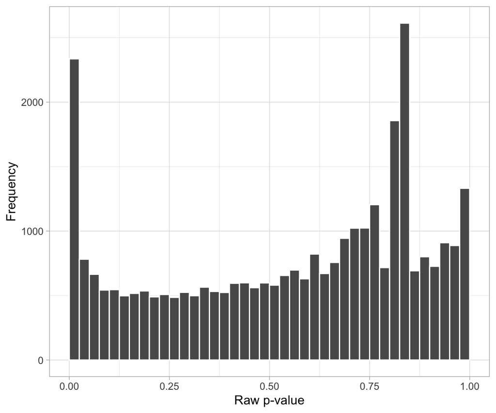

```r
ggplot(as.data.frame(res), aes(x=pvalue)) +
  geom_histogram(color="white", breaks=seq(0, 1, by=0.025)) +
  xlab("Raw p-value") +
  ylab("Frequency") +
  theme_light()
```

**Question** : quelles sont les améliorations apportées par la prise en compte de cet effet “donneur” ?

## 2.3 Elimination de l’effet batch pour la visualisation

Maintenant que l’analyse différentielle est correctement réalisée, nous pouvons visualiser les résultats sous la forme d’une heatmap, en sélectionnant les gènes différentiellement exprimés au seuil de 5% :

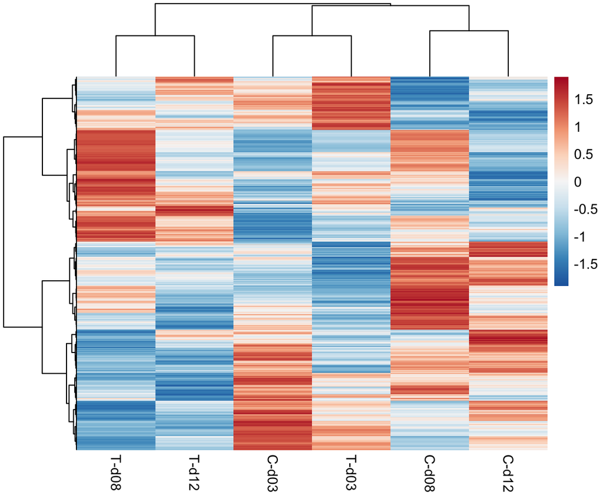

```r
DE_genes <- res %>%
  as.data.frame() %>%
  filter(padj <= 0.05) %>%
  rownames()
mat_hm <- assay(rlog(dds))
pheatmap(mat_hm[DE_genes,],
         scale="row",
         show_rownames=FALSE,
         clustering_distance_rows="euclidean",
         clustering_distance_cols="euclidean",
         clustering_method="ward.D",
         color=colorRampPalette(rev(brewer.pal(9, "RdBu")))(200))
```

Dans cette heatmap, les échantillons ne clusterisent pas par traitement alors que nous avons pourtant sélectionné les gènes selon ce critère. Une solution est d’*ajuster* la matrice (sur l’effet donneur) avant de produire la figure grâce à la fonction `removeBatchEffect()` :

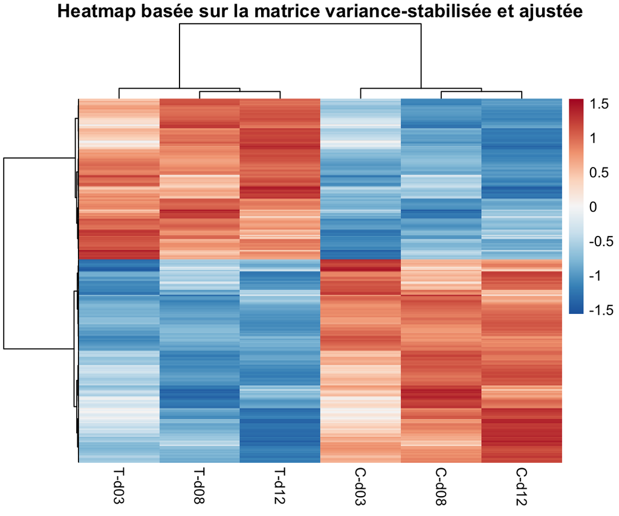

```r
mat_hm_adj <- removeBatchEffect(mat_hm, batch=target$donor)
pheatmap(mat_hm_adj[DE_genes,],
         scale="row",
         show_rownames=FALSE,
         clustering_distance_rows="euclidean",
         clustering_distance_cols="euclidean",
         clustering_method="ward.D",
         color=colorRampPalette(rev(brewer.pal(9, "RdBu")))(200),
         main="Heatmap basée sur la matrice variance-stabilisée et ajustée")
```

**Remarques** :

- Il ne faut pas confondre l’**ajustement** dans le **design du modèle** linéaire généralisé de DESeq2 (les données restent inchangées) et l’ajustement directement sur la **matrice d’expression** (les valeurs sont alors modifiées) dans une optique de **visualisation**.
- Si la heatmap contient trop de cellules (en lignes et/ou colonnes) alors il se peut que l’affichage et le rendu soient contraints par le nombre de pixels de l’écran. Ces deux articles décrivent ce “problème” : [ici](https://bioinfo-fr.net/creer-des-heatmaps-a-partir-de-grosses-matrices-en-r) et [là](https://jokergoo.github.io/2020/06/30/rasterization-in-complexheatmap/).
- Les heatmaps sont de formidables outils de visualisation et on peut imaginer une personnalisation à l’infini, notamment avec le package [ComplexHeatmap](https://jokergoo.github.io/ComplexHeatmap-reference/book/).

## 2.4 Identifiants des gènes

Les identifiants utilisés pour l’analyse différentielle sont issus d’*ensembl* (et du fichier d’annotation au format GFF ou GTF) et ne sont pas toujours pratiques pour l’interprétation. Le code ci-dessous est une manière parmi tant d’autres de récupérer les noms des gènes correspondants :

```r
ensembl <- useEnsembl(biomart="ensembl", dataset="hsapiens_gene_ensembl", version=102)
# attr <- listAttributes(ensembl)$name
# attr[grepl("ensembl_gene_id", attr)]
# attr[grepl("entrezgene", attr)]
# attr[grepl("external_gene_name", attr)]
bm <- getBM(attributes=c("ensembl_gene_id", "external_gene_name"), mart=ensembl)
head(bm)
```

```
##   ensembl_gene_id external_gene_name
## 1 ENSG00000210049              MT-TF
## 2 ENSG00000211459            MT-RNR1
## 3 ENSG00000210077              MT-TV
## 4 ENSG00000210082            MT-RNR2
## 5 ENSG00000209082             MT-TL1
## 6 ENSG00000198888             MT-ND1
```

Le tableau `bm` permet de faire le lien entre les identifiants *ensembl* sous la forme `ENSG000...` et les noms humainement interprétables. Ici, il est nécessaire d’explorer ce tableau afin de vérifier la présence de doublons dans chacune des colonnes. Commençons par les *gene names* :

```r
bm %>%
  filter(!is.na(external_gene_name)) %>%
  pull(external_gene_name) %>%
  duplicated() %>%
  any()
```

```
## [1] TRUE
```

```r
dup_gene_names <- bm %>%
  filter(!is.na(external_gene_name)) %>%
  filter(duplicated(external_gene_name)) %>%
  pull(external_gene_name)
bm %>%
  filter(external_gene_name %in% dup_gene_names) %>%
  arrange(external_gene_name) %>%
  tail(n=10)
```

```
##      ensembl_gene_id external_gene_name
## 8278 ENSG00000225618           ZNRD1ASP
## 8279 ENSG00000235814           ZNRD1ASP
## 8280 ENSG00000229653           ZNRD1ASP
## 8281 ENSG00000204623           ZNRD1ASP
## 8282 ENSG00000284588                ZP2
## 8283 ENSG00000103310                ZP2
## 8284 ENSG00000288360             ZSWIM4
## 8285 ENSG00000132003             ZSWIM4
## 8286 ENSG00000285443                ZYX
## 8287 ENSG00000159840                ZYX
```

Plusieurs identifiants *ensembl* correspondent à un même *gene name* ! Regardons ensuite les identifiants *ensembl* :

```r
bm %>%
  filter(!is.na(ensembl_gene_id)) %>%
  pull(ensembl_gene_id) %>%
  duplicated() %>%
  any()
```

```
## [1] FALSE
```

Les identifiants *ensembl* sont uniques et nous avons un seul *gene name* par identifiant *ensembl*. Nous allons donc pouvoir les remplacer facilement :

```r
DE_genes <- res %>%
  as.data.frame() %>%
  filter(padj <= 0.0001 & (log2FoldChange > 2.5 | log2FoldChange < -3.5)) %>%
  rownames()
print(DE_genes)
```

```
## [1] "ENSG00000111537" "ENSG00000112116" "ENSG00000115008" "ENSG00000115523" "ENSG00000124191" "ENSG00000124766"
## [7] "ENSG00000136634" "ENSG00000169860"
```

```r
DE_gene_names <- bm %>%
  arrange(ensembl_gene_id) %>%
  filter(ensembl_gene_id %in% DE_genes)
print(DE_gene_names)
```

```
##   ensembl_gene_id external_gene_name
## 1 ENSG00000111537               IFNG
## 2 ENSG00000112116              IL17F
## 3 ENSG00000115008               IL1A
## 4 ENSG00000115523               GNLY
## 5 ENSG00000124191               TOX2
## 6 ENSG00000124766               SOX4
## 7 ENSG00000136634               IL10
## 8 ENSG00000169860              P2RY1
```

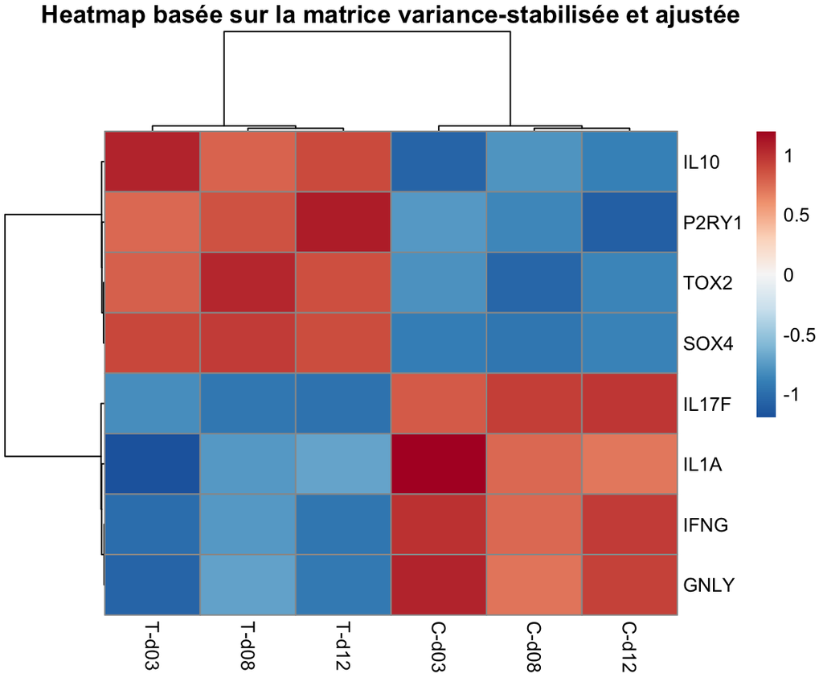

```r
pheatmap(mat_hm_adj[DE_gene_names$ensembl_gene_id,],
         scale="row",
         labels_row=DE_gene_names$external_gene_name,
         clustering_distance_rows="euclidean",
         clustering_distance_cols="euclidean",
         clustering_method="ward.D",
         color=colorRampPalette(rev(brewer.pal(9, "RdBu")))(200),
         main="Heatmap basée sur la matrice variance-stabilisée et ajustée")
```

**Remarque** : nous avons utilisé le package R biomaRt pour associer les identifiants *ensembl* aux *gene names*, mais les packages AnnotationHub et AnnotationDbi (entre autres) peuvent être intéressants. Ce [document](https://www.bioconductor.org/help/course-materials/2019/CSAMA/materials/lectures/lecture-08a-annotation.html#1) recense différents outils disponibles et leurs fonctionnements.

# 3 Du gène au *gene-set*

L’analyse conduite ci-dessus nous a permis de détecter un certain nombre de gènes dérégulés par l’effet du traitement. Nous pouvons alors nous demander si ces gènes appartiennent préférentiellement à des *pathways*/voies/catégories (i.e. ensembles de gènes cohérents biologiquement) connus dans la littérature. Autrement dit, nous allons rechercher des *gene-sets* enrichis en gènes différentiellement exprimés, i.e. des *gene-sets* perturbés par l’effet du traitement.

De nombreuses méthodes et plusieurs packages R et applications web existent pour réaliser cette analyse fonctionnelle de manière automatisée. Bien que toutes (ou presque) les publications utilisant du RNA-Seq présentent des résultats issus d’une analyse d’enrichissement, les méthodes statistiques employées sont souvent mal décrites ([Wijesooriya et al, 2022](https://doi.org/10.1371/journal.pcbi.1009935)).

La construction/comparaison de ces méthodes étant un domaine de recherche à part entière, nous utiliserons ici une seule méthode qui est à la fois performante et fiable : CAMERA (*Competitive Gene Set Test Accounting for Inter-gene Correlation*) ([Wu et al, 2012](https://academic.oup.com/nar/article/40/17/e133/2411151)). Cette méthode est disponible au sein du package R `limma` et permet de tester soit :

1. si un *gene-set* est enrichi en gènes up-régulés ou en gènes down-régulés (test bilatéral en supposant que le *gene-set* est **directionnel**),
2. si un *gene-set* est enrichi en gènes différentiels (up et down confondus, en supposant que le *gene-set* est **non-directionnel**).

Les principaux avantages de CAMERA sont les suivants :

- même si un changement d’expression n’est pas statistiquement significatif à l’échelle d’un gène, plusieurs petits changements au sein d’un même *gene-set* peuvent se révéler intéressants.
- la prise en compte de la corrélation au sein des *gene-sets* : deux gènes d’un même *gene-set* auront tendance à être davantage corrélés que deux gènes pris au hasard dans le génome.

## 3.1 Préparation des données

La première étape est d’importer dans R les *gene-sets* que l’on souhaite tester : par exemple les *pathways* KEGG, les *GO terms* de la catégorie *Molecular Function*, etc… Ici, nous importons uniquement les *pathways* KEGG en utilisant le package R gage :

```r
kegg <- kegg.gsets(species="human", id.type="kegg")$kg.sets
print(head(kegg, 3))
```

```
## $`hsa00010 Glycolysis / Gluconeogenesis`
##  [1] "10327"  "124"    "125"    "126"    "127"    "128"    "130"    "130589" "131"    "160287" "1737"   "1738"
## [13] "2023"   "2026"   "2027"   "217"    "218"    "219"    "2203"   "221"    "222"    "223"    "224"    "226"
## [25] "229"    "230"    "2538"   "2597"   "26330"  "2645"   "2821"   "3098"   "3099"   "3101"   "387712" "3939"
## [37] "3945"   "3948"   "441531" "501"    "5105"   "5106"   "5160"   "5161"   "5162"   "5211"   "5213"   "5214"
## [49] "5223"   "5224"   "5230"   "5232"   "5236"   "5313"   "5315"   "55276"  "55902"  "57818"  "669"    "7167"
## [61] "80201"  "83440"  "84532"  "8789"   "92483"  "92579"  "9562"
##
## $`hsa00020 Citrate cycle (TCA cycle)`
##  [1] "1431"  "1737"  "1738"  "1743"  "2271"  "3417"  "3418"  "3419"  "3420"  "3421"  "4190"  "4191"  "47"    "48"
## [15] "4967"  "50"    "5091"  "5105"  "5106"  "5160"  "5161"  "5162"  "55753" "6389"  "6390"  "6391"  "6392"  "8801"
## [29] "8802"  "8803"
##
## $`hsa00030 Pentose phosphate pathway`
##  [1] "132158" "2203"   "221823" "226"    "229"    "22934"  "230"    "23729"  "2539"   "25796"  "2821"   "414328"
## [13] "51071"  "5211"   "5213"   "5214"   "5226"   "5236"   "55276"  "5631"   "5634"   "6120"   "64080"  "6888"
## [25] "7086"   "729020" "8277"   "84076"  "8789"   "9104"   "9563"
```

```r
length(kegg)
```

```
## [1] 348
```

Les *pathways* KEGG sont importés sous la forme d’une liste : chaque élément est un vecteur (ensemble) de gènes représentant un *pathway*. Aussi, les gènes sont caractérisés par des numéros qui correspondent à leur identifiant *Entrez* (NCBI). On peut vérifier que chaque *gene-set* contient des identifiants uniques (i.e. pas de doublons) et qu’aucun *gene-set* n’est présent deux fois :

```r
any(sapply(kegg, function(x) any(duplicated(x))))
```

```
## [1] FALSE
```

```r
any(duplicated(lapply(kegg, function(x) sort(x))))
```

```
## [1] FALSE
```

L’étape suivante consiste à transformer les identifiants *ensembl* utilisés pour l’analyse différentielle en identifiants de type *Entrez*. Pour cela, nous pouvons utiliser la même méthode que précédemment et vérifier la présence de doublons :

```r
bm <- getBM(attributes=c("ensembl_gene_id", "entrezgene_id"), mart=ensembl)
head(bm)
```

```
##   ensembl_gene_id entrezgene_id
## 1 ENSG00000210049            NA
## 2 ENSG00000211459            NA
## 3 ENSG00000210077            NA
## 4 ENSG00000210082            NA
## 5 ENSG00000209082            NA
## 6 ENSG00000198888          4535
```

```r
bm %>%
  filter(!is.na(ensembl_gene_id)) %>%
  pull(ensembl_gene_id) %>%
  duplicated() %>%
  any()
```

```
## [1] TRUE
```

```r
dup_ensembl <- bm %>%
  filter(!is.na(ensembl_gene_id)) %>%
  filter(duplicated(ensembl_gene_id)) %>%
  pull(ensembl_gene_id)
bm %>%
  filter(ensembl_gene_id %in% dup_ensembl) %>%
  arrange(ensembl_gene_id) %>%
  head(n=10)
```

```
##    ensembl_gene_id entrezgene_id
## 1  ENSG00000004866          7982
## 2  ENSG00000004866         93655
## 3  ENSG00000063587         10838
## 4  ENSG00000063587     105373378
## 5  ENSG00000076928          9138
## 6  ENSG00000076928     100505585
## 7  ENSG00000088298         55741
## 8  ENSG00000088298     111089941
## 9  ENSG00000099977          1652
## 10 ENSG00000099977     100037417
```

On remarque que plusieurs identifiants *Entrez* pointent vers un même identifiant *ensembl*, mais cela ne posera pas de problème pour l’analyse d’enrichissement. La situation inverse est plus problématique :

```r
bm %>%
  filter(!is.na(entrezgene_id)) %>%
  pull(entrezgene_id) %>%
  duplicated() %>%
  any()
```

```
## [1] TRUE
```

```r
dup_entrez <- bm %>%
  filter(!is.na(entrezgene_id)) %>%
  filter(duplicated(entrezgene_id)) %>%
  pull(entrezgene_id)
bm %>%
  filter(entrezgene_id %in% dup_entrez) %>%
  arrange(entrezgene_id) %>%
  head(n=10)
```

```
##    ensembl_gene_id entrezgene_id
## 1  ENSG00000236342            23
## 2  ENSG00000225989            23
## 3  ENSG00000231129            23
## 4  ENSG00000232169            23
## 5  ENSG00000206490            23
## 6  ENSG00000236149            23
## 7  ENSG00000204574            23
## 8  ENSG00000281879            28
## 9  ENSG00000175164            28
## 10 ENSG00000276016            29
```

Plusieurs identifiants *ensembl* (et donc plusieurs log2(Fold-Change), P-valeurs…) correspondent à un même identifiant *Entrez*. Les *pathways* étant définis par des identifiants *Entrez*, nous devons choisir quel identifiant *ensembl* associer à chaque *Entrez*. Ici, nous choisons l’identifiant *ensembl* ayant l’expression la plus forte, mais nous pourrions choisir un tout autre critère :

```r
res <- res %>%
  as.data.frame() %>%
  mutate(ensembl_gene_id=rownames(res)) %>%
  inner_join(bm, by="ensembl_gene_id", multiple="all") %>%
  arrange(desc(baseMean)) %>%
  filter(!is.na(entrezgene_id)) %>%
  filter(!duplicated(entrezgene_id))
print(head(res))
```

```
##   baseMean log2FoldChange      lfcSE      pvalue       padj ensembl_gene_id entrezgene_id
## 1 615460.0     0.16162398 0.09395140 0.009413978 0.10519755 ENSG00000075624            60
## 2 598624.2     0.05468944 0.07862636 0.319484930 0.75184010 ENSG00000100453          3002
## 3 428040.3    -0.09076801 0.08600251 0.113641577 0.48043456 ENSG00000166710           567
## 4 409505.7     0.07194170 0.07626481 0.189826112 0.60658306 ENSG00000074800          2023
## 5 407566.1     0.18814987 0.09673261 0.003371158 0.04877515 ENSG00000184009            71
## 6 400827.1     0.03958300 0.07516372 0.463933241 0.83995735 ENSG00000111640          2597
```

CAMERA utilise en entrée l’ensemble des statistiques de test des gènes (obtenues avec DESeq2). On écarte cependant celles correspondant à des gènes trop faiblement exprimés : ces gènes apportent peu d’information et ont tendance à bruiter l’analyse.

**Remarque** : la statistique de test d’un gène est défini comme :

$$\text{stat} =
\frac{\log_2(\text{Fold-Change})}{\text{standard-error}}$$

Elle est plus “robuste” que le log<sub>2</sub>(FC) car elle prend en compte la précision de l’estimation de celui-ci.

```r
res <- res %>%
  mutate(stat=log2FoldChange/lfcSE) %>%
  filter(baseMean > 50)
statistic <- res %>% pull(stat)
names(statistic) <- res %>% pull(entrezgene_id)
statistic <- statistic[!is.na(statistic)]
print(head(statistic, 15))
```

```
##         60       3002        567       2023         71       2597       3312       5315       1938       3326
##  1.7202934  0.6955611 -1.0554111  0.9433145  1.9450512  0.5266237  1.3583172 -0.4326258  0.4743739  0.9867149
##       3106       3939      10399       7178       6194
## -1.6388882  1.0675929  0.3608865 -0.9797787 -0.1892027
```

Ce vecteur contient toutes les statistiques de test associées aux identifiants *Entrez* et est prêt à être utilisé par CAMERA.

## 3.2 CAMERA directionnel

Par défaut, CAMERA est en mode “directionnel” :

```r
res.cam.dir <- cameraPR(statistic=statistic, index=kegg)
print(head(res.cam.dir))
```

```
##                                                                        NGenes Direction       PValue          FDR
## hsa04060 Cytokine-cytokine receptor interaction                           141      Down 5.153411e-39 1.793387e-36
## hsa05323 Rheumatoid arthritis                                              61      Down 3.100664e-24 5.395155e-22
## hsa04061 Viral protein interaction with cytokine and cytokine receptor     50      Down 3.759151e-22 4.360615e-20
## hsa05332 Graft-versus-host disease                                         29      Down 1.938684e-21 1.686655e-19
## hsa04940 Type I diabetes mellitus                                          29      Down 2.120838e-17 1.476103e-15
## hsa05321 Inflammatory bowel disease                                        50      Down 1.397720e-14 8.106776e-13
```

```r
print(sum(res.cam.dir$FDR <= 0.05))
```

```
## [1] 23
```

Le *gene-set* `hsa04060 Cytokine-cytokine receptor interaction` est détecté comme étant plutôt down-régulé, et on peut visualiser les statistiques de test des gènes qui le composent :

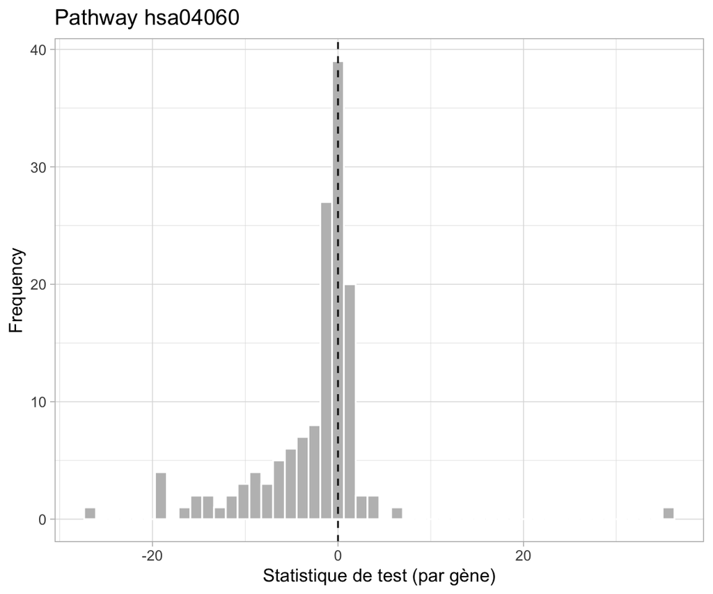

```r
res %>%
  filter(entrezgene_id %in% kegg[["hsa04060 Cytokine-cytokine receptor interaction"]]) %>%
  ggplot(aes(x=stat)) +
  geom_histogram(bins=50, color="white", fill="grey") +
  geom_vline(xintercept=0, linetype="dashed") +
  xlab("Statistique de test (par gène)") +
  ylab("Frequency") +
  ggtitle("Pathway hsa04060") +
  theme_light()
```

## 3.3 CAMERA non directionnel

Pour tester l’enrichissement en gènes dérégulés (up et down confondus), on peut utiliser les arguments `directional=FALSE` et `use.ranks=TRUE`. CAMERA utilisera alors les valeurs absolues des statistiques de test puis un test non-paramétrique (contrairement à la version directionnelle qui utilise un test paramétrique).

```r
res.cam.nondir <- cameraPR(statistic=statistic, index=kegg, directional=FALSE, use.ranks=TRUE)
print(head(res.cam.nondir))
```

```
##                                                                        NGenes       PValue          FDR
## hsa04060 Cytokine-cytokine receptor interaction                           141 2.912927e-08 1.013699e-05
## hsa04659 Th17 cell differentiation                                         96 1.458258e-06 1.779736e-04
## hsa05321 Inflammatory bowel disease                                        50 1.534255e-06 1.779736e-04
## hsa04061 Viral protein interaction with cytokine and cytokine receptor     50 4.498641e-06 3.913817e-04
## hsa04630 JAK-STAT signaling pathway                                       103 6.494067e-06 4.519871e-04
## hsa05330 Allograft rejection                                               28 9.542865e-06 5.534862e-04
```

```r
print(sum(res.cam.nondir$FDR <= 0.05))
```

```
## [1] 102
```

**Remarque** : il n’y a plus de colonne “Direction” en sortie de CAMERA car la notion de Up ou Down n’existe plus avec un test non directionnel.

```r
intersect(res.cam.nondir %>% filter(FDR < 0.01) %>% rownames(),
          res.cam.dir %>% filter(FDR > 0.9) %>% rownames())
```

```
## [1] "hsa04670 Leukocyte transendothelial migration"     "hsa04218 Cellular senescence"
## [3] "hsa05146 Amoebiasis"                               "hsa04625 C-type lectin receptor signaling pathway"
## [5] "hsa04934 Cushing syndrome"                         "hsa04927 Cortisol synthesis and secretion"
## [7] "hsa04024 cAMP signaling pathway"                   "hsa05203 Viral carcinogenesis"
## [9] "hsa04020 Calcium signaling pathway"
```

Illustrons les résultats pour le *gene-set* `hsa04670 Leukocyte transendothelial migration` qui apparait enrichi en gènes différentiels (alors qu’il n’était pas significatif avec l’analyse directionnelle précédente) :

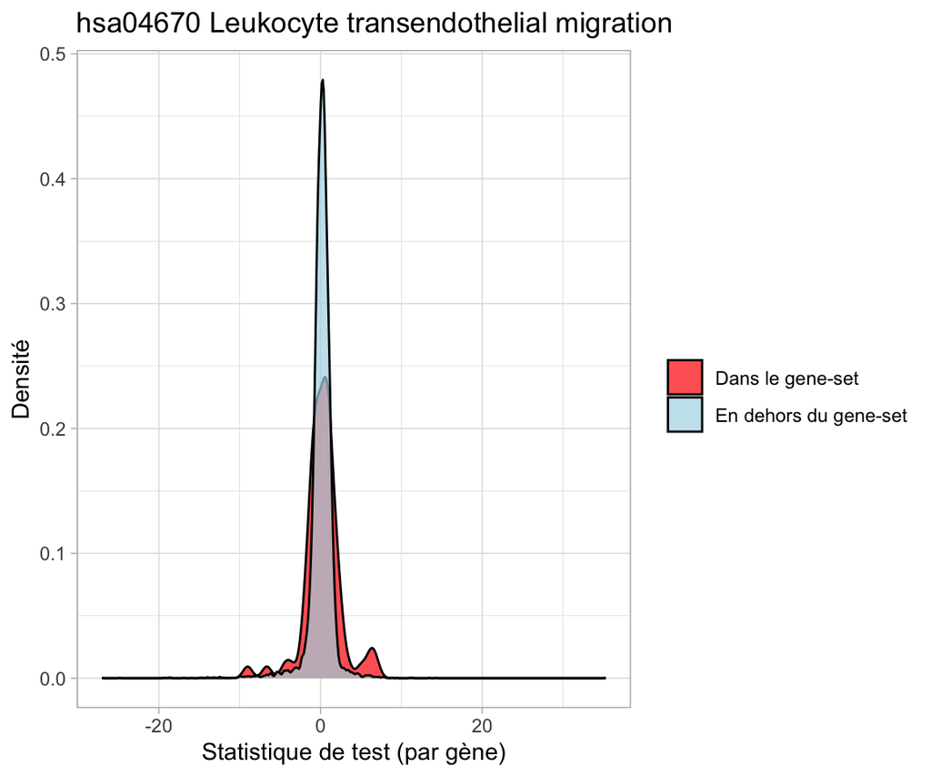

```r
res %>%
  mutate(gs=ifelse(entrezgene_id %in% kegg[["hsa04670 Leukocyte transendothelial migration"]],
                   "Dans le gene-set", "En dehors du gene-set")) %>%
  ggplot(aes(x=stat, fill=gs)) +
  geom_density(alpha=0.7) +
  scale_fill_manual(values=c("red", "lightblue")) +
  labs(fill="") +
  xlab("Statistique de test (par gène)") +
  ylab("Densité") +
  ggtitle("hsa04670 Leukocyte transendothelial migration") +
  theme_light()
```

Comme attendu, les statistiques de test des gènes dans le *gene-set* `hsa04670` ont tendance à être plus extrêmes que celles des gènes en dehors du *gene-set*.

**Remarque** : CAMERA est une méthode dite “compétitive” car elle compare le comportement des gènes dans un *gene-set* avec le comportement des gènes en dehors du *gene-set*.

## 3.4 Questions pour aller plus loin

- Quels *gene-sets* tester (KEGG, GO, Reactome, WikiPathways…) ? Impact sur l’ajustement des p-valeurs ?
- Quelle base de données choisir pour importer les *gene-sets* : packages R (EnrichmentBrowser, msigdbr, gage, …) ? sites web ? fichiers GMT ?
- Quel est l’impact de la version de l’annotation ?
- La notion de “directionnalité” du *gene-set* est importante : ses gènes sont-ils plutôt tous up ? plutôt tous down ? ou un mélange des deux ?
- Comment faire lorsqu’on doit tester l’enrichissement pour plusieurs comparaisons (e.g. 0h - 4h - 8h) ?
- Que faire avec les organismes plus ou moins bien annotés ?

**Quelques références** :

- Jelle J. Goeman, Peter Bühlmann, *Analyzing gene expression data in terms of gene sets: methodological issues*, Bioinformatics, Volume 23, Issue 8, April 2007, Pages 980–987 [[Lien](https://doi.org/10.1093/bioinformatics/btm051)]
- Nguyen, TM., Shafi, A., Nguyen, T. et al. *Identifying significantly impacted pathways: a comprehensive review and assessment*. Genome Biol 20, 203 (2019) [[Lien](https://genomebiology.biomedcentral.com/articles/10.1186/s13059-019-1790-4)]
- Maleki F, Ovens K, Hogan DJ, Kusalik AJ. *Gene Set Analysis: Challenges, Opportunities, and Future Research.* Front Genet. 2020 Jun 30;11:654 [[Lien](https://doi.org/10.3389/fgene.2020.00654)]
- Ludwig Geistlinger, Gergely Csaba, Mara Santarelli et al, *Toward a gold standard for benchmarking gene set enrichment analysis*, Briefings in Bioinformatics, Volume 22, Issue 1, January 2021, Pages 545–556 [[Lien](https://academic.oup.com/bib/article/22/1/545/5722384)]
- Mark Ziemann, Barry Schroeter, Anusuiya Bora, *Two subtle problems with overrepresentation analysis*, Bioinformatics Advances, Volume 4, Issue 1, 2024, vbae159 [[Lien](https://doi.org/10.1093/bioadv/vbae159)]

# 4 Analyse statistique d’un design complexe

Dans les sections ci-dessus, nous avons analysé des données provenant de designs expérimentaux **simples**. Or, pour répondre à certaines questions biologiques, il est nécessaire de créer des designs dits **complexes**, i.e. incluants plusieurs facteurs.

Nous allons étudier ici des données RNA-Seq provenant d’un tel design : l’objectif est d’évaluer l’effet d’un traitement (T vs C) sur deux souches d’une bactérie (WT et KO). Les deux facteurs/variables étudié(e)s sont donc le traitement et la souche, chacun prenant deux niveaux/modalités.

**Question** : que peut-on faire à partir de ces données et comment pouvons-nous les analyser ?

## 4.1 Ecriture de l’interaction dans le modèle

```r
rm(list=ls())
load("data_interaction.RData")
ls()
```

```
## [1] "counts" "target"
```

```r
print(target)
```

```
##         label strain treatment replicate
## WT-C-1 WT-C-1     WT         C        r1
## WT-C-2 WT-C-2     WT         C        r2
## WT-C-3 WT-C-3     WT         C        r3
## WT-T-1 WT-T-1     WT         T        r1
## WT-T-2 WT-T-2     WT         T        r2
## WT-T-3 WT-T-3     WT         T        r3
## KO-C-1 KO-C-1     KO         C        r1
## KO-C-2 KO-C-2     KO         C        r2
## KO-C-3 KO-C-3     KO         C        r3
## KO-T-1 KO-T-1     KO         T        r1
## KO-T-2 KO-T-2     KO         T        r2
## KO-T-3 KO-T-3     KO         T        r3
```

```r
print(head(counts))
```

```
##       WT-C-1 WT-C-2 WT-C-3 WT-T-1 WT-T-2 WT-T-3 KO-C-1 KO-C-2 KO-C-3 KO-T-1 KO-T-2 KO-T-3
## gene1    412    590    656    698    537    737     35     47     36      9     21     19
## gene2   7483  11099   9825  20678  13621  19940  13170  14153  11198   8475   9479   8464
## gene3   7005  11450  10400  11932   9691  14038   8533  10837   7824   6814   8318   6668
## gene4   6774  12938   9603  13754  11554  16687   4405   4446   3661   4045   6133   4075
## gene5   2706   4018   3604   4927   3839   5663   4526   5084   4326   4435   4985   4502
## gene6  25276  42273  38634  49580  40575  56964  36755  40690  30480  28131  32439  27851
```

```r
# mettre WT en reference de strain et C en reference de treatment
target$strain <- factor(target$strain, levels=c("WT", "KO"))
target$treatment <- factor(target$treatment, levels=c("C", "T"))
```

Le code R ci-dessous permet de créer l’objet `dds` avec le design adéquat et de réaliser les 3 étapes de l’analyse différentielle (normalisation, estimation de la dispersion et modèle linéaire généralisé) :

```r
dds <- DESeqDataSetFromMatrix(countData=counts,
                              colData=target,
                              design=~replicate + strain + treatment + strain:treatment)
dds <- estimateSizeFactors(dds)
dds <- estimateDispersions(dds)
dds <- nbinomWaldTest(dds)
resultsNames(dds)
```

```
## [1] "Intercept"           "replicate_r2_vs_r1"  "replicate_r3_vs_r1"  "strain_KO_vs_WT"     "treatment_T_vs_C"
## [6] "strainKO.treatmentT"
```

## 4.2 Visualisation de l’interaction

L’analyse en composante principale permet de visualiser la structure des données :

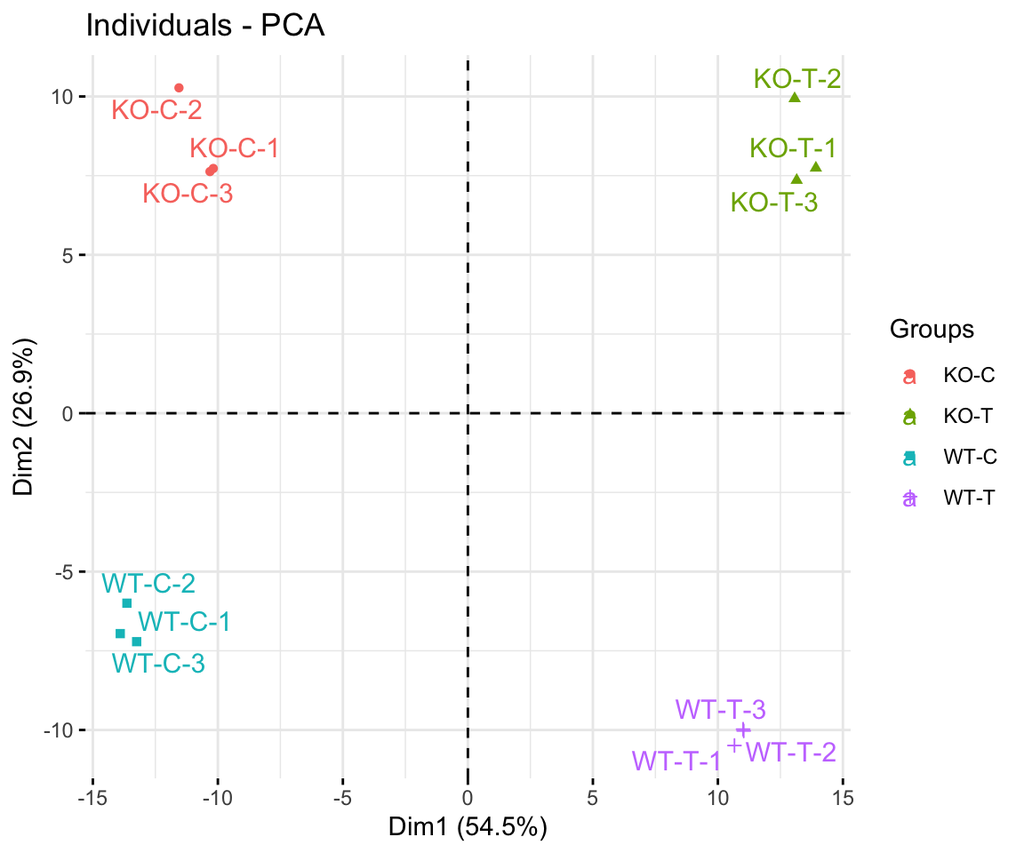

```r
rld <- rlog(dds)
pca <- PCA(t(assay(rld)), scale.unit=FALSE, ncp=3, graph=FALSE)
fviz_pca_ind(pca, axes=c(1, 2), repel=TRUE, mean.point=FALSE,
             habillage=factor(paste(target$strain, target$treatment, sep="-")))
```

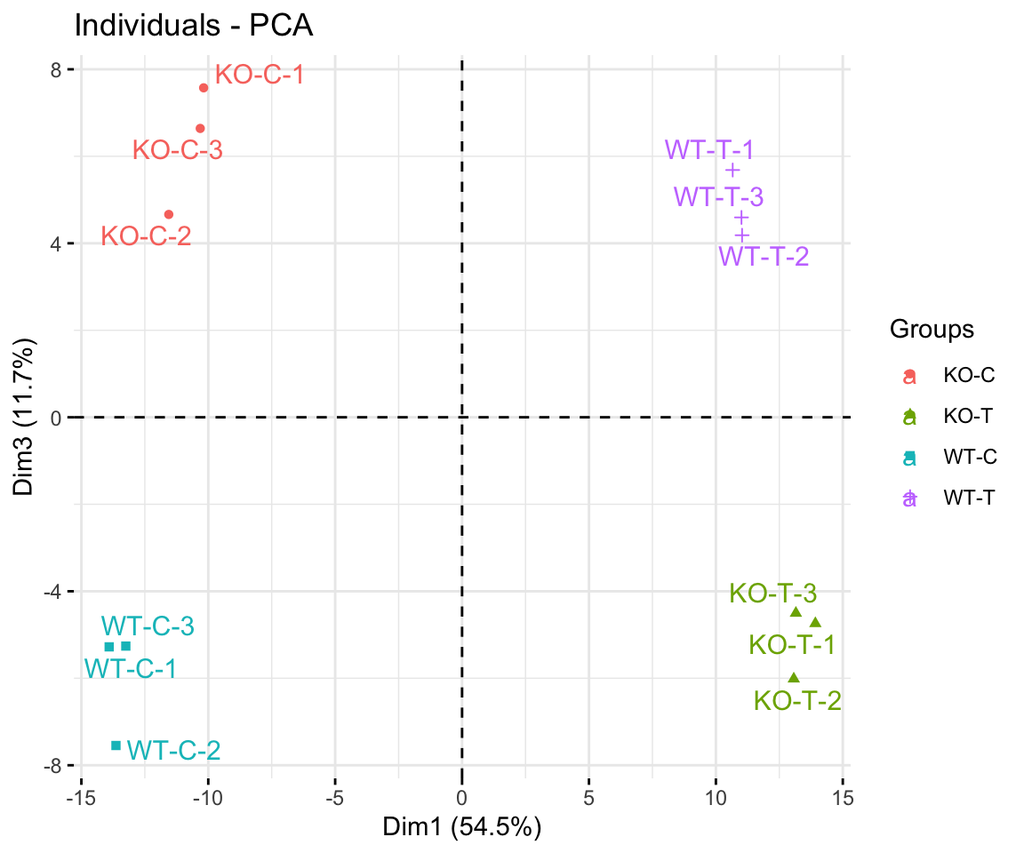

```r
fviz_pca_ind(pca, axes=c(1, 3), repel=TRUE, mean.point=FALSE,
             habillage=factor(paste(target$strain, target$treatment, sep="-")))
```

On peut également visualiser l’interaction pour un gène spécifique (bien choisi) :

```r
ncounts <- counts(dds, norm=TRUE)
d <- data.frame(target, ncounts=ncounts["gene914",])
print(d)
```

```
##         label strain treatment replicate   ncounts
## WT-C-1 WT-C-1     WT         C        r1  57.68749
## WT-C-2 WT-C-2     WT         C        r2  43.65947
## WT-C-3 WT-C-3     WT         C        r3  44.75770
## WT-T-1 WT-T-1     WT         T        r1 491.84167
## WT-T-2 WT-T-2     WT         T        r2 276.67419
## WT-T-3 WT-T-3     WT         T        r3 338.98342
## KO-C-1 KO-C-1     KO         C        r1 275.29097
## KO-C-2 KO-C-2     KO         C        r2 116.71415
## KO-C-3 KO-C-3     KO         C        r3 266.30771
## KO-T-1 KO-T-1     KO         T        r1  44.58641
## KO-T-2 KO-T-2     KO         T        r2  23.61180
## KO-T-3 KO-T-3     KO         T        r3  27.25240
```

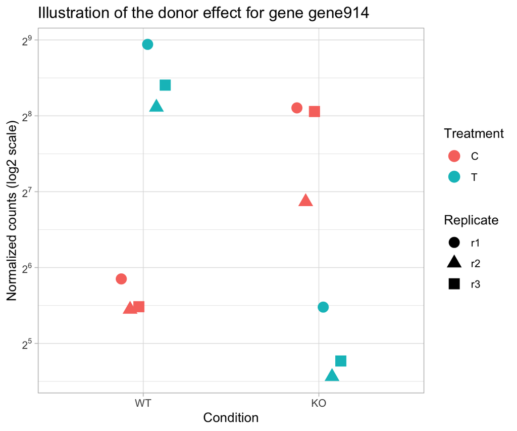

```r
ggplot(d, aes(x=strain, y=ncounts, color=treatment, shape=replicate)) +
  geom_beeswarm(dodge.width=0.3, size=4) +
  scale_y_continuous(trans=log2_trans(),
    breaks=trans_breaks("log2", function(x) 2^x),
    labels=trans_format("log2", math_format(2^.x))) +
  xlab("Condition") +
  ylab("Normalized counts (log2 scale)") +
  labs(shape="Replicate", color="Treatment") +
  ggtitle("Illustration of the donor effect for gene gene914") +
  theme_light()
```

## 4.3 Ecriture des contrastes

Nous pouvons ensuite utiliser DESeq2 et des contrastes adaptés pour evaluer l’effet du traitement sur chaque souche et ensuite comparer ces deux effets :

1. T vs C pour les WT
2. T vs C pour les KO
3. différence entre (2) et (1)

```r
# ExploreModelMatrix() pour lancer l'application Shiny
res_TvsC.WT <- lfcShrink(dds, contrast=c(0, 0, 0, 0, 1, 0), type="ashr", quiet=TRUE)
res_TvsC.KO <- lfcShrink(dds, contrast=c(0, 0, 0, 0, 1, 1), type="ashr", quiet=TRUE)
res_interaction <- lfcShrink(dds, contrast=c(0, 0, 0, 0, 0, 1), type="ashr", quiet=TRUE)
summary(res_TvsC.WT, alpha=0.05)
```

```
##
## out of 1716 with nonzero total read count
## adjusted p-value < 0.05
## LFC > 0 (up)       : 487, 28%
## LFC < 0 (down)     : 451, 26%
## outliers [1]       : 0, 0%
## low counts [2]     : 0, 0%
## (mean count < 0)
## [1] see 'cooksCutoff' argument of ?results
## [2] see 'independentFiltering' argument of ?results
```

```r
summary(res_TvsC.KO, alpha=0.05)
```

```
##
## out of 1716 with nonzero total read count
## adjusted p-value < 0.05
## LFC > 0 (up)       : 463, 27%
## LFC < 0 (down)     : 506, 29%
## outliers [1]       : 0, 0%
## low counts [2]     : 0, 0%
## (mean count < 0)
## [1] see 'cooksCutoff' argument of ?results
## [2] see 'independentFiltering' argument of ?results
```

```r
summary(res_interaction, alpha=0.05)
```

```
##
## out of 1716 with nonzero total read count
## adjusted p-value < 0.05
## LFC > 0 (up)       : 398, 23%
## LFC < 0 (down)     : 430, 25%
## outliers [1]       : 0, 0%
## low counts [2]     : 0, 0%
## (mean count < 0)
## [1] see 'cooksCutoff' argument of ?results
## [2] see 'independentFiltering' argument of ?results
```

Afin de comparer les effets du traitement chez les WT et chez les KO, nous assemblons les résultats au sein d’un même tableau et nous créons de nouvelles variables indiquant d’une part si un gène est en interaction (`DE_int`) et d’autre part si les deux effets sont significatifs (`DE_both_strains`). Ensuite nous pouvons tracer la figure :

```r
d <- data.frame(gene=rownames(res_TvsC.WT),
                log2FC_TvsC.WT=res_TvsC.WT$log2FoldChange,
                padj_TvsC.WT=res_TvsC.WT$padj,
                log2FC_TvsC.KO=res_TvsC.KO$log2FoldChange,
                padj_TvsC.KO=res_TvsC.KO$padj,
                log2FC_int=res_interaction$log2FoldChange,
                padj_int=res_interaction$padj)
d <- d %>%
  mutate(DE_int=ifelse(!is.na(padj_int) & padj_int <= 0.05, "Yes", "No"),
         DE_both_strains=ifelse(!is.na(padj_TvsC.WT) & padj_TvsC.WT <= 0.05 & !is.na(padj_TvsC.KO) & padj_TvsC.KO <= 0.05, "Yes", "No"))
print(head(d))
```

```
##    gene log2FC_TvsC.WT padj_TvsC.WT log2FC_TvsC.KO padj_TvsC.KO  log2FC_int    padj_int DE_int DE_both_strains
## 1 gene1    -0.09689838 5.178970e-01     -0.6354706 6.810186e-03 -0.47905538 0.052770555     No              No
## 2 gene2     0.49374402 8.312332e-06     -0.1073933 3.601136e-01 -0.58749593 0.000169735    Yes              No
## 3 gene3    -0.05797363 6.122993e-01      0.0907722 4.114685e-01  0.14584864 0.357576667     No              No
## 4 gene4     0.13107436 3.794633e-01      0.5116283 6.742476e-04  0.31723594 0.112832737     No              No
## 5 gene5     0.08540833 4.220296e-01      0.3899746 7.871748e-05  0.28317668 0.044938613    Yes              No
## 6 gene6     0.09137723 3.921496e-01      0.1185208 2.488123e-01  0.02705004 0.882849983     No              No
```

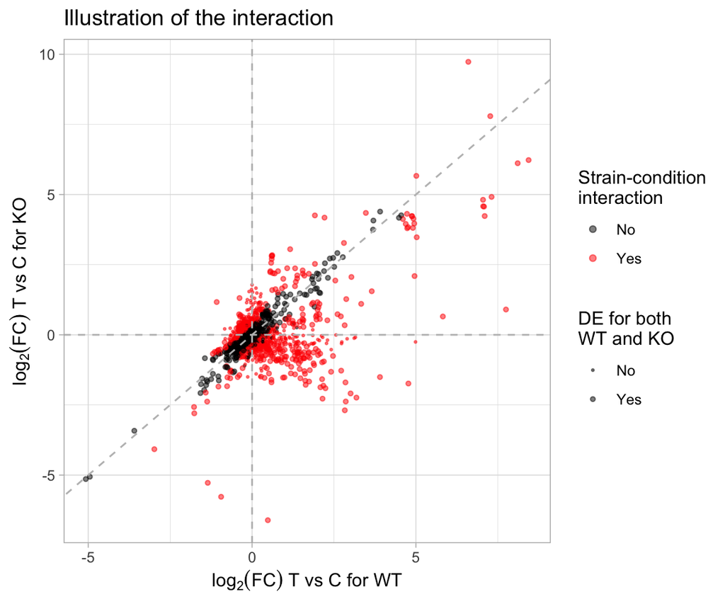

```r
ggplot(d, aes(x=log2FC_TvsC.WT, y=log2FC_TvsC.KO, color=DE_int, size=DE_both_strains)) +
  geom_point(alpha=0.5) +
  scale_color_manual(values=c("Yes"="red", "No"="black")) +
  scale_size_manual(values=c("Yes"=1, "No"=0.4)) +
  geom_hline(yintercept=0, lty=2, color="grey") +
  geom_vline(xintercept=0, lty=2, color="grey") +
  geom_abline(slope=1, intercept=0, lty=2, color="grey") +
  labs(color="Strain-condition\ninteraction", size="DE for both\nWT and KO") +
  xlab(bquote(log[2](FC)~"T vs C for WT")) +
  ylab(bquote(log[2](FC)~"T vs C for KO")) +
  ggtitle("Illustration of the interaction") +
  theme_light()
```

Sur cette figure, les points éloignés de la diagonale (droite $Y = X$) correspondent aux gènes en interaction, i.e. pour lesquels l’effet du traitement diffère selon la souche. Autrement dit, le log2(Fold-Change) chez les WT est très différent du log2(Fold-Change) chez les KO. Cette différence d’effets est significative lorsque le point est rouge (au seuil de 5%), et les effets individuels (chez les WT et KO) sont significatifs simultanément si le point est agrandi.

## 4.4 Heatmap

On peut sélectionner ces gènes et les visualiser sous la forme d’une heatmap (en ajustant sur l’effet du réplicat) :

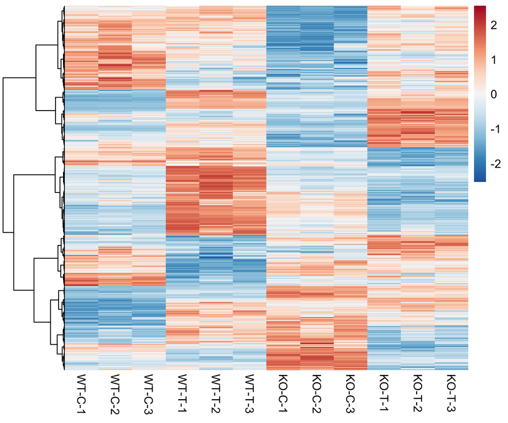

```r
int_genes <- d %>%
  filter(padj_int <= 0.05) %>%
  pull(gene)
mat_hm <- assay(rlog(dds))
mat_hm_adj <- removeBatchEffect(mat_hm, batch=target$replicate)
pheatmap(mat_hm_adj[int_genes,],
         scale="row",
         show_rownames=FALSE,
         cluster_cols=FALSE,
         clustering_distance_rows="euclidean",
         clustering_method="ward.D",
         color=colorRampPalette(rev(brewer.pal(9, "RdBu")))(200))
```

Le code ci-dessous permet de visualiser les log2(Fold-Change) :

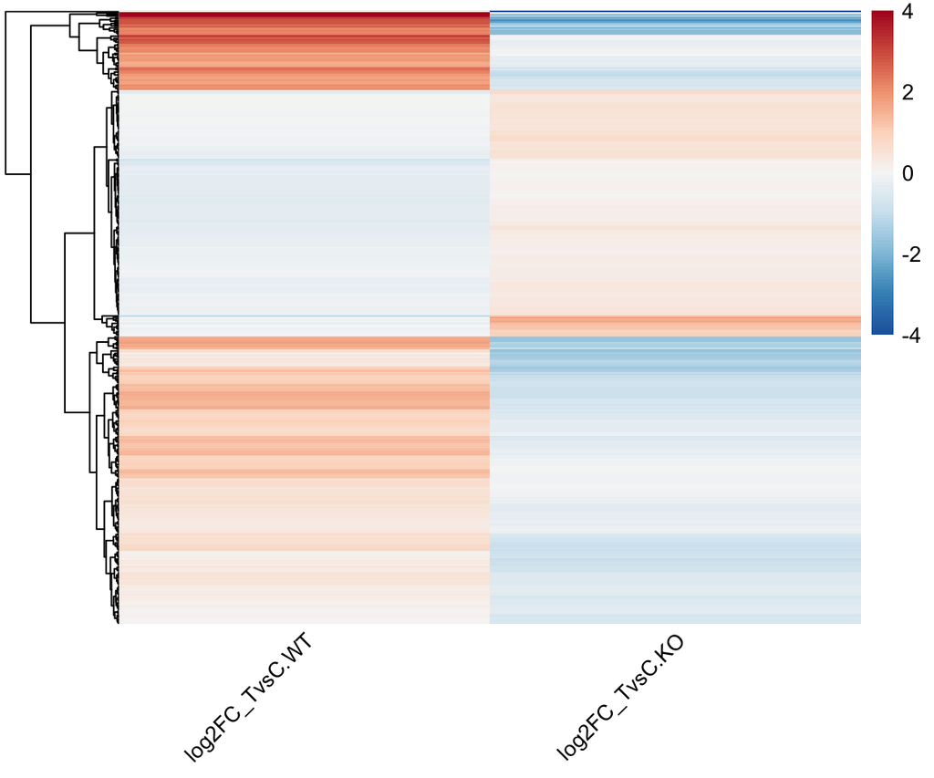

```r
rownames(d) <- d$gene
d <- d %>%
  filter(padj_int < 0.005 & sign(log2FC_TvsC.WT) != sign(log2FC_TvsC.KO)) %>%
  dplyr::select(log2FC_TvsC.WT, log2FC_TvsC.KO) %>%
  as.matrix()
pheatmap(d,
         scale="none",
         show_rownames=FALSE,
         cluster_cols=FALSE,
         clustering_distance_rows="euclidean",
         angle_col=45,
         fontsize_row=5,
         color=colorRampPalette(rev(brewer.pal(9, "RdBu")))(100),
         breaks=seq(-4, 4, length=101))
```

**Question** : comment analyser un design expérimental comportant plus de 3 facteurs d’intérêt ?

# Liens et références intéressants

### RNA-Seq

- Chaine YouTube [StatQuest](https://www.youtube.com/c/joshstarmer/videos)
- Site [DoItYourself Transcriptomics](https://diytranscriptomics.com/)
- Site [RNA-Seqlopedia](https://rnaseq.uoregon.edu/)
- Article sur la normalisation : Ciaran Evans, Johanna Hardin, Daniel M Stoebel, *Selecting between-sample RNA-Seq normalization methods from the perspective of their assumptions*, Briefings in Bioinformatics, Volume 19, Issue 5, September 2018, Pages 776–792 [[Lien](https://academic.oup.com/bib/article/19/5/776/3056951)]

### R

- Livre [*R for Data Science*](https://r4ds.had.co.nz/)
- Livre [*R Cookbook*](https://rc2e.com/)
- Livre [*Modern Data Science with R*](https://mdsr-book.github.io/mdsr2e/)
- Livre [*Computational Genomics with R*](https://compgenomr.github.io/book/)
- Livre [*ggplot2: elegant graphics for data analysis*](https://ggplot2-book.org/index.html)
- Site de [référence ggplot2](https://ggplot2.tidyverse.org/reference/)
- Site [extensions ggplot2](https://exts.ggplot2.tidyverse.org/gallery/)
- Site [*A ggplot2 Tutorial for Beautiful Plotting in R*](https://www.cedricscherer.com/2019/08/05/a-ggplot2-tutorial-for-beautiful-plotting-in-r/)
- Package R patchwork
- Livre [*Circular Visualization in R*](https://jokergoo.github.io/circlize_book/book/)
- Livre [ComplexHeatmap](https://jokergoo.github.io/ComplexHeatmap-reference/book/)
- Palettes de [couleurs](https://github.com/EmilHvitfeldt/r-color-palettes)

# Informations sur la session R